# Quem são os nossos clientes? (versão simplificada)

Segmentação de clientes com cluster hierárquico e distância de Gower

Autor

MAT02053 – Estatística Aplicada a Negócios (UFRGS)

# 1. Problema de negócio e setup

## O problema de negócio

Imagine que nós somos a **equipe de dados de uma rede de varejo**. Hoje, toda campanha de marketing (cupom, e-mail, folheto) é enviada **igual para todos os clientes**. O resultado é conhecido: quem gosta de vinho premium recebe o mesmo cupom de quem só compra itens em promoção, e ninguém se sente “visto” pela loja.

A saída é **segmentar** a base: dividir os clientes em **grupos parecidos entre si e diferentes dos outros grupos**, para tratar cada grupo de um jeito. Em estatística, isso é um problema de **análise de agrupamentos** (*clustering*): não existe uma “resposta certa” para conferir, e é o algoritmo que sugere os grupos a partir dos dados.

Por que não criar os grupos com uma **regra fixa**, por exemplo “renda alta” e “renda baixa”? Porque o comportamento de compra depende de **várias coisas ao mesmo tempo** (quanto gasta, onde compra, se tem filhos em casa, se usa promoções). Uma regra só com a renda esconde diferenças importantes, e um corte como “ganha mais de X por ano” é arbitrário. Os algoritmos de clustering olham para todas as variáveis juntas.

O que vamos fazer hoje:

1. **Entender e preparar os dados** de clientes;
2. **Agrupar** os clientes com o **cluster hierárquico**, primeiro só com variáveis numéricas (distância euclidiana) e depois também com categóricas (distância de Gower);
3. **Comparar** os resultados das duas réguas e escolher os grupos que vão para o marketing;
4. **Entregar “fichas de segmento”**: para cada grupo, um nome, um perfil em linguagem de negócio e uma ação de marketing sugerida.

A entrega final **não é um gráfico bonito**: é a ficha que o time de marketing consegue usar na segunda-feira.

## Sobre os dados

Vamos usar a base *Customer Personality Analysis*, com **2.240 clientes** de uma empresa de varejo (compras de vinho, frutas, carnes, peixes, doces e ouro; canais de compra; resposta a campanhas). O arquivo `marketing_campaign.csv` já está na pasta da aula: **nada é baixado durante a aula**.

A fonte não informa a moeda dos valores. **Vamos supor que os valores monetários (renda e gastos) estão em dólares (US$)**, para facilitar a leitura.

## Um mínimo de R para começar

*(Pode pular se a turma já souber R.)* Estas ideias bastam para acompanhar a aula:

- **Objetos** guardam coisas. Criamos um objeto com a “setinha” `<-`.
- **Funções** fazem coisas. Elas têm nome e parênteses: `mean(x)`, `round(3.14159, 2)`.
- O **pipe** `|>` passa o resultado da esquerda para a função da direita. Lemos como **“e então”**.
- Uma **tabela** de dados (no tidyverse, chamada de *tibble*) tem uma coluna por variável. Pegamos uma coluna com o cifrão: `clientes$Income` é a coluna `Income` da tabela `clientes`.
- Para o R encontrar os arquivos, abra sempre a aula pelo arquivo **`clustering.Rproj`** (duplo clique): o RStudio já “entra” na pasta certa.

```r
# 1. Problema de negócio e setup ----

# AULA: Quem são os nossos clientes? (MAT02053 - UFRGS)
# Somos a equipe de dados de uma rede de varejo e vamos segmentar os clientes
# para personalizar as campanhas. Rode o script bloco a bloco (Ctrl + Enter).
# Este arquivo é gerado a partir de aula_clustering_simplificada.qmd (veja o HTML com as explicações).

# Criando um objeto chamado "gastos" com quatro valores
gastos <- c(100, 250, 300, 150)

# Aplicando uma função ao objeto: a média dos gastos
mean(gastos)
```

```
[1] 200
```

```r
# O mesmo cálculo usando o pipe: "pegue gastos E ENTÃO calcule a média"
gastos |> mean()
```

```
[1] 200
```

```r
# Pipes podem ser encadeados: média e então arredondamento com 1 casa
gastos |> mean() |> round(1)
```

```
[1] 200
```

## Pacotes

Pacotes são “caixas de ferramentas” que estendem o R. O bloco abaixo **instala apenas os pacotes que ainda não estão no seu computador** (isso só precisa acontecer uma vez) e depois os carrega.

```r
# Lista de pacotes usados na aula
pacotes <- c("tidyverse",   # manipulação (dplyr), leitura (readr) e gráficos (ggplot2)
             "cluster")     # daisy() (distância de Gower)

# Quais ainda não estão instalados?
faltando <- pacotes[!sapply(pacotes, requireNamespace, quietly = TRUE)]

# Instala só os que faltam (se não faltar nenhum, não faz nada)
if (length(faltando) > 0) install.packages(faltando)

# Carrega os pacotes
library(tidyverse)
library(cluster)
```

## Lendo os dados

**Importante**

Abra sempre a aula pelo arquivo **`clustering.Rproj`**. Assim o RStudio já “entra” na pasta certa e o R encontra o `marketing_campaign.csv`.

O arquivo é separado por **TAB** (a tecla de tabulação), e não por vírgula, apesar de se chamar `.csv`. Por isso usamos `read_tsv()`. Se usássemos `read_csv()` (que espera vírgulas), o R não encontraria nenhuma vírgula e leria **cada linha inteira como uma única coluna**, com tudo misturado. Se a tabela vier com 1 coluna, é esse o problema.

```r
# Conferindo se estamos na pasta certa antes de ler os dados
if (!file.exists("marketing_campaign.csv")) {
  stop("Não encontrei o arquivo marketing_campaign.csv. ",
       "Feche o RStudio e abra o arquivo clustering.Rproj ",
       "(ou use o menu Session > Set Working Directory > Choose Directory ",
       "e escolha a pasta clustering).")
}

# read_tsv() lê arquivos separados por TAB
clientes_raw <- read_tsv("marketing_campaign.csv")

# Primeira olhada: quantas linhas e colunas, e o tipo de cada coluna
glimpse(clientes_raw)
```

```
Rows: 2,240
Columns: 29
$ ID                  <dbl> 5524, 2174, 4141, 6182, 5324, 7446, 965, 6177, 485…
$ Year_Birth          <dbl> 1957, 1954, 1965, 1984, 1981, 1967, 1971, 1985, 19…
$ Education           <chr> "Graduation", "Graduation", "Graduation", "Graduat…
$ Marital_Status      <chr> "Single", "Single", "Together", "Together", "Marri…
$ Income              <dbl> 58138, 46344, 71613, 26646, 58293, 62513, 55635, 3…
$ Kidhome             <dbl> 0, 1, 0, 1, 1, 0, 0, 1, 1, 1, 1, 0, 0, 1, 0, 0, 1,…
$ Teenhome            <dbl> 0, 1, 0, 0, 0, 1, 1, 0, 0, 1, 0, 0, 0, 1, 0, 0, 1,…
$ Dt_Customer         <chr> "04-09-2012", "08-03-2014", "21-08-2013", "10-02-2…
$ Recency             <dbl> 58, 38, 26, 26, 94, 16, 34, 32, 19, 68, 11, 59, 82…
$ MntWines            <dbl> 635, 11, 426, 11, 173, 520, 235, 76, 14, 28, 5, 6,…
$ MntFruits           <dbl> 88, 1, 49, 4, 43, 42, 65, 10, 0, 0, 5, 16, 61, 2, …
$ MntMeatProducts     <dbl> 546, 6, 127, 20, 118, 98, 164, 56, 24, 6, 6, 11, 4…
$ MntFishProducts     <dbl> 172, 2, 111, 10, 46, 0, 50, 3, 3, 1, 0, 11, 225, 3…
```

[output cut: 16 more lines]

São **2.240 clientes** e **29 colunas**. Na seção 2, o `summary()` vai mostrar que `Income` (renda anual) tem alguns valores ausentes (`NA`): cuidaremos deles na preparação dos dados.

# 2. Estatísticas descritivas

Antes de agrupar qualquer coisa, precisamos **conhecer os clientes**. Esta seção responde, uma pergunta de marketing de cada vez, “como é a nossa base?”. Ela também vai nos mostrar **problemas nos dados** que teremos de resolver na seção 3.

## Visão geral da base

**Pergunta do marketing:** *quais informações temos sobre cada cliente, e há algo estranho nos números?*

O `glimpse()` da seção anterior já mostrou o tipo de cada coluna. Agora o `summary()` resume as colunas numéricas (mínimo, quartis, média, máximo e quantidade de `NA`). Vamos olhar só algumas colunas-chave para a tabela caber na tela.

```r
# 2. Estatísticas descritivas ----

# Selecionando algumas colunas-chave e pedindo o resumo estatístico de cada uma
clientes_raw |>
  select(Year_Birth, Income, Kidhome, Teenhome, Recency, MntWines, NumStorePurchases) |>
  summary()
```

```
   Year_Birth       Income          Kidhome          Teenhome
 Min.   :1893   Min.   :  1730   Min.   :0.0000   Min.   :0.0000
 1st Qu.:1959   1st Qu.: 35303   1st Qu.:0.0000   1st Qu.:0.0000
 Median :1970   Median : 51382   Median :0.0000   Median :0.0000
 Mean   :1969   Mean   : 52247   Mean   :0.4442   Mean   :0.5062
 3rd Qu.:1977   3rd Qu.: 68522   3rd Qu.:1.0000   3rd Qu.:1.0000
 Max.   :1996   Max.   :666666   Max.   :2.0000   Max.   :2.0000
                NA's   :24
    Recency         MntWines       NumStorePurchases
 Min.   : 0.00   Min.   :   0.00   Min.   : 0.00
 1st Qu.:24.00   1st Qu.:  23.75   1st Qu.: 3.00
 Median :49.00   Median : 173.50   Median : 5.00
 Mean   :49.11   Mean   : 303.94   Mean   : 5.79
 3rd Qu.:74.00   3rd Qu.: 504.25   3rd Qu.: 8.00
 Max.   :99.00   Max.   :1493.00   Max.   :13.00
```

Três coisas chamam atenção. A **renda máxima é US$ 666.666**, muito acima do terceiro quartil (US$ 68.522) e da média (US$ 52.247): é suspeita. O `Income` tem **24 valores ausentes** (`NA`). E o **ano de nascimento mínimo é 1893**, o que daria um cliente com mais de 120 anos: os três menores valores são 1893, 1899 e 1900, idades implausíveis (o seguinte já é 1940), provavelmente erros de digitação. Vamos investigar a renda com um gráfico.

## Renda: quem ganha o quê?

**Pergunta do marketing:** *qual é a faixa de renda típica dos nossos clientes?*

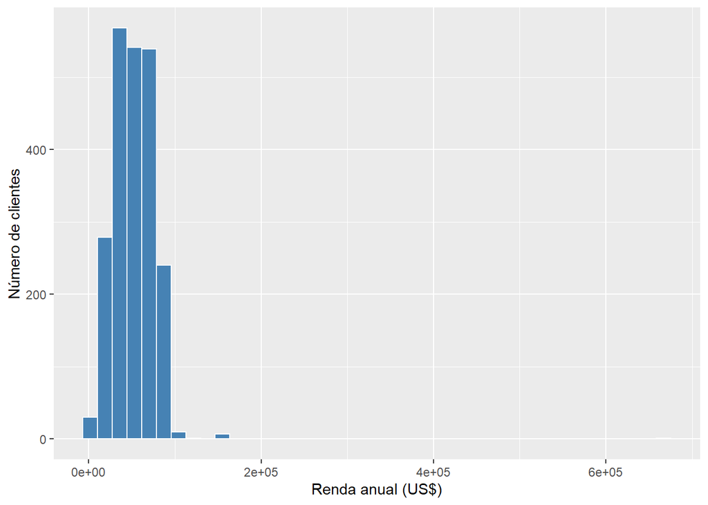

Histograma da renda anual (Income)

```r
# Histograma da renda: cada barra conta quantos clientes caem numa faixa de renda
clientes_raw |>
  ggplot(aes(x = Income)) +
  geom_histogram(bins = 40, fill = "steelblue", color = "white", na.rm = TRUE) +
  labs(x = "Renda anual (US$)", y = "Número de clientes")
```

Quase todos os clientes estão entre 0 e 160 mil, mas o eixo vai até 666 mil por causa de **um único cliente** com renda 666.666. As rendas seguintes mais altas são 162.397, 160.803 e 157.733, ou seja, esse ponto está **muito isolado** (um *outlier*). Isso distorce médias e, mais adiante, distorceria as distâncias entre clientes. Trataremos disso na seção 3.

## Gasto total: quanto os clientes gastam?

**Pergunta do marketing:** *os clientes gastam valores parecidos, ou existe um grupo que gasta muito mais que os outros?*

Há seis colunas de gasto, todas começando com `Mnt`, de **“Montante”**: o montante gasto em compras de cada categoria nos últimos 2 anos (`MntWines` = vinhos, `MntFruits` = frutas, `MntMeatProducts` = carnes, `MntFishProducts` = peixes, `MntSweetProducts` = doces e `MntGoldProds` = produtos “ouro”).

Uma observação sobre `MntGoldProds`: os produtos “ouro” (*gold products*) são os itens **de luxo**, a linha *premium* da empresa. Eles medem um gasto discricionário de alto padrão, diferente dos produtos do dia a dia, como carnes, peixes, frutas, doces e vinhos.

Somamos as seis para obter o gasto total de cada cliente, apenas para este gráfico.

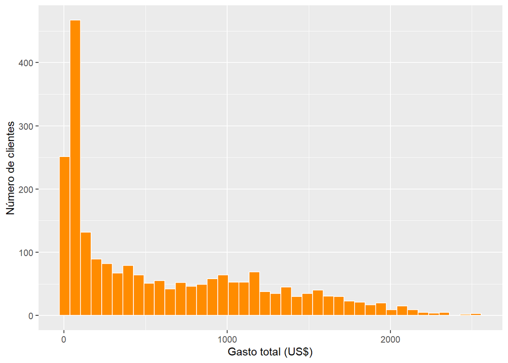

Distribuição do gasto total (soma das seis categorias)

```r
# Gasto total = soma das seis colunas de valor gasto (as que começam com "Mnt", de "Montante")
# Obs.: MntGoldProds = produtos "ouro", ou seja, os itens de luxo (linha premium)
gasto_total_tmp <- clientes_raw |>
  mutate(gasto_total = MntWines + MntFruits + MntMeatProducts +
           MntFishProducts + MntSweetProducts + MntGoldProds)

# Histograma do gasto total
gasto_total_tmp |>
  ggplot(aes(x = gasto_total)) +
  geom_histogram(bins = 40, fill = "darkorange", color = "white") +
  labs(x = "Gasto total (US$)", y = "Número de clientes")
```

```r
# Comparando mediana e média do gasto total
gasto_total_tmp |>
  summarise(mediana = median(gasto_total), media = mean(gasto_total))
```

```
# A tibble: 1 × 2
  mediana media
    <dbl> <dbl>
1     396  606.
```

A distribuição é **assimétrica à direita**: muitos clientes gastam pouco e poucos gastam muito. A **mediana é 396**, mas a **média é 605,8**; a média é puxada para cima pelos grandes gastadores. Variáveis assim têm uma “cauda longa” que domina as distâncias entre clientes. Por isso, na seção 3, vamos aplicar o **logaritmo** nos gastos antes de agrupar: ele “comprime” a cauda e deixa os clientes mais comparáveis.

## Renda e gasto andam juntos?

**Pergunta do marketing:** *quem ganha mais também gasta mais?*

Um **gráfico de dispersão** coloca um ponto por cliente: a renda no eixo x e o gasto total no eixo y. Deixamos de fora, **só neste gráfico**, os clientes sem renda e o cliente de renda 666.666 (senão todos os outros ficariam espremidos à esquerda).

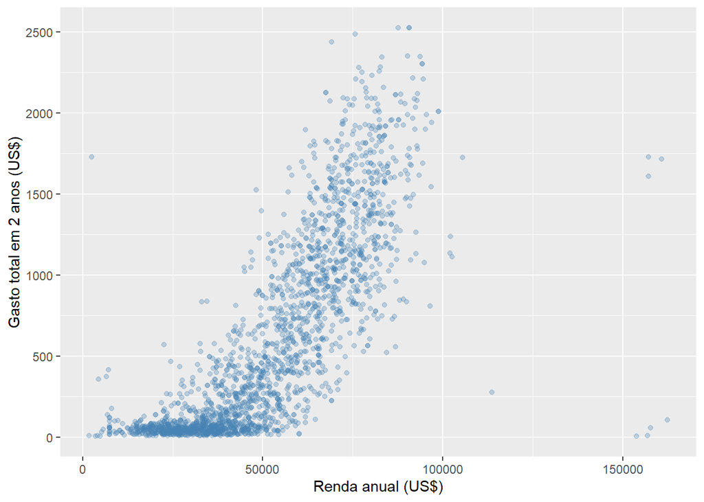

Renda anual vs. gasto total (um ponto por cliente)

```r
# Só para o gráfico: sem renda ausente e sem a renda extrema
renda_gasto_tmp <- gasto_total_tmp |>
  filter(!is.na(Income), Income <= 200000)

# Gráfico de dispersão: um ponto por cliente (alpha deixa os pontos semitransparentes)
renda_gasto_tmp |>
  ggplot(aes(x = Income, y = gasto_total)) +
  geom_point(alpha = 0.3, color = "steelblue") +
  labs(x = "Renda anual (US$)", y = "Gasto total em 2 anos (US$)")
```

```r
# Correlação entre renda e gasto (de -1 a 1; perto de 1 = sobem juntos)
cor(renda_gasto_tmp$Income, renda_gasto_tmp$gasto_total)
```

```
[1] 0.7926503
```

Renda e gasto **sobem juntos** (correlação de **0,79**): quem ganha mais tende a gastar mais. Mas a relação não é uma linha reta perfeita: abaixo de uns US$ 40 mil por ano, quase ninguém gasta muito; acima disso, o gasto se espalha bastante, e há clientes de renda parecida com gastos muito diferentes. É por isso que vale olhar **várias variáveis ao mesmo tempo**, e não só a renda.

## Em que os clientes gastam?

**Pergunta do marketing:** *quais categorias de produto geram mais receita?*

As seis colunas `Mnt*` estão “lado a lado”. Para fazer um gráfico com uma barra por categoria, usamos `pivot_longer()`, que as empilha em duas colunas: o nome da categoria e o valor.

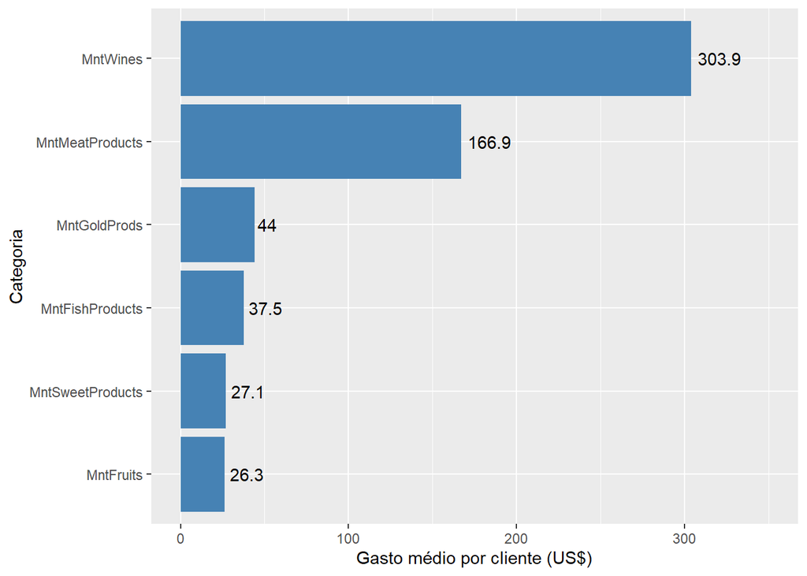

Gasto médio por categoria de produto

```r
# Gasto médio de cada categoria, em formato "longo" (uma linha por cliente e categoria)
gasto_categoria <- clientes_raw |>
  select(starts_with("Mnt")) |>                         # só as seis colunas de gasto
  pivot_longer(everything(),                            # empilha todas as colunas
               names_to = "categoria", values_to = "gasto") |>
  group_by(categoria) |>                                # um grupo por categoria
  summarise(gasto_medio = mean(gasto))                  # média por categoria

# Gráfico de barras, ordenado do menor para o maior gasto médio,
# com o valor escrito na ponta de cada barra (geom_text)
gasto_categoria |>
  ggplot(aes(x = reorder(categoria, gasto_medio), y = gasto_medio)) +
  geom_col(fill = "steelblue") +
  geom_text(aes(label = round(gasto_medio, 1)), hjust = -0.15) +
  coord_flip() +                                        # barras na horizontal
  expand_limits(y = 350) +                              # espaço para o número da maior barra
  labs(x = "Categoria", y = "Gasto médio por cliente (US$)")
```

**Vinhos** lideram com gasto médio de US$ 303,9, cerca de metade do gasto médio total (US$ 605,8), seguidos por **carnes** (US$ 166,9). Frutas (US$ 26,3), doces (US$ 27,1), peixes (US$ 37,5) e produtos “ouro” (US$ 44,0) pesam bem menos. Vinho e carne são, portanto, as categorias que mais “movem” as diferenças entre clientes.

## Por onde os clientes compram?

**Pergunta do marketing:** *em quais canais (loja, site, catálogo) e com que uso de promoções os clientes compram?*

Antes, o que significa cada canal: `NumStorePurchases` são as compras **na loja física**, `NumWebPurchases` as compras **pelo site** e `NumCatalogPurchases` as compras **pelo catálogo** (todas nos últimos 2 anos). Comprar pelo catálogo, comum na época em que a base foi criada (por volta de 2012-2014), funciona assim: a loja envia uma revista ou folheto (pelo correio ou por e-mail) com fotos, códigos e preços dos produtos; o cliente escolhe os itens pelo código e faz o pedido à distância (por telefone, formulário impresso ou pedido direto), sem ir à loja e sem navegar pelo site. No Brasil, o exemplo clássico são as revistas da **Natura**, da **Avon** ou do **Boticário**: você escolhe o produto no catálogo e encomenda com a consultora ou com a central.

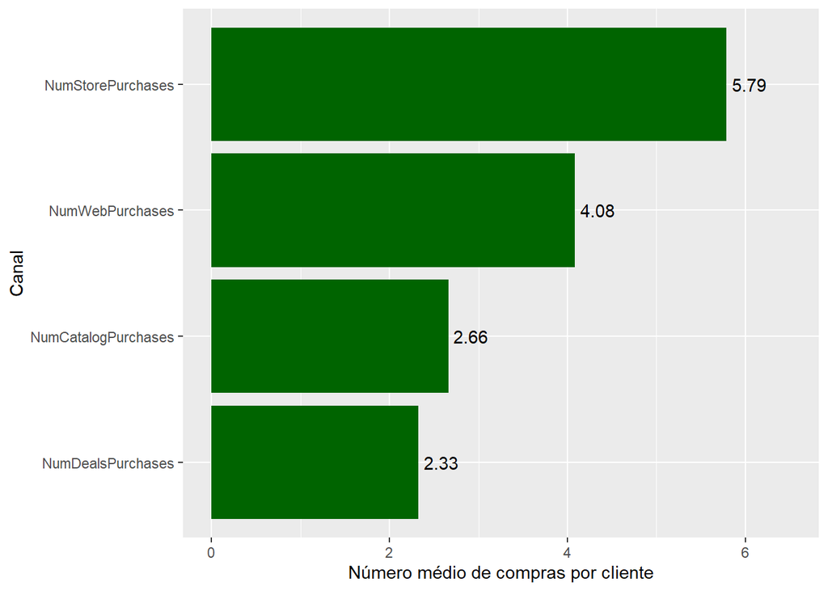

Número médio de compras por canal

```r
# Média de compras em cada canal (NumDealsPurchases = compras feitas com desconto;
# NumCatalogPurchases = pedidos à distância pelo catálogo, como nas revistas da Natura/Avon/Boticário)
compras_canal <- clientes_raw |>
  select(NumStorePurchases, NumWebPurchases, NumCatalogPurchases, NumDealsPurchases) |>
  pivot_longer(everything(), names_to = "canal", values_to = "compras") |>
  group_by(canal) |>
  summarise(compras_medias = mean(compras))

# Gráfico de barras com a média de compras por canal (e o valor na ponta da barra)
compras_canal |>
  ggplot(aes(x = reorder(canal, compras_medias), y = compras_medias)) +
  geom_col(fill = "darkgreen") +
  geom_text(aes(label = round(compras_medias, 2)), hjust = -0.15) +
  coord_flip() +
  expand_limits(y = 6.5) +
  labs(x = "Canal", y = "Número médio de compras por cliente")
```

```r
# Quantos clientes têm compras com desconto <= soma dos três canais? (veja o quadro abaixo)
clientes_raw |>
  count(desconto_cabe_nos_canais = NumDealsPurchases <=
          NumWebPurchases + NumCatalogPurchases + NumStorePurchases)
```

```
# A tibble: 2 × 2
  desconto_cabe_nos_canais     n
  <lgl>                    <int>
1 FALSE                        3
2 TRUE                      2237
```

A **loja física** é o canal mais usado (5,79 compras por cliente em média), seguida pelo **site** (4,08) e pelo **catálogo** (2,66). As compras com desconto têm média de 2,33. Como a média esconde diferenças entre clientes, esperamos que **grupos diferentes** usem canais diferentes.

**DicaPara investigar: as compras com desconto são contadas duas vezes?**

`NumDealsPurchases` é um **canal** a mais, ou uma **parte** das compras dos outros três canais? Ou seja: uma compra com desconto feita na loja conta, ao mesmo tempo, em `NumStorePurchases` **e** em `NumDealsPurchases`? A fonte dos dados não diz. Há um indício de que sim: em **2.237 dos 2.240** clientes, as compras com desconto são **no máximo** a soma das compras no site, no catálogo e na loja, como seria de esperar se elas estivessem “dentro” desses canais.

Se for isso, a mesma compra aparece em **duas variáveis**, que passam a carregar informação repetida (uma forma de **multicolinearidade**): o comportamento “comprar” pesaria duas vezes na distância entre os clientes. Na vida real, a pergunta certa é: **vá conferir com quem montou a base** como cada coluna foi calculada. Nesta aula, mantemos as quatro variáveis, mas fica o alerta.

## Perfil familiar e escolaridade

**Pergunta do marketing:** *os clientes têm filhos em casa, e qual o nível de escolaridade?*

`Kidhome` conta as crianças em casa e `Teenhome`, os adolescentes. Somando os dois, temos o total de filhos em casa.

**NotaDe onde vem o número de filhos?**

Na vida real, essa informação é **difícil de obter**. A loja vê o que o cliente compra, mas não sabe quantos filhos ele tem, a não ser que exista um **cadastro detalhado** em que o próprio cliente **informe** isso (por exemplo, num programa de fidelidade). Por isso, ela costuma ter lacunas e pode estar desatualizada (os filhos crescem e saem de casa, e o cadastro fica igual). Aqui temos a sorte de ter essa coluna completa.

Nos gráficos de barras, primeiro **contamos** os clientes com `count()` e depois desenhamos as barras com essa contagem, escrevendo o número em cima de cada barra (`geom_text()`). Assim, o gráfico já mostra os números.

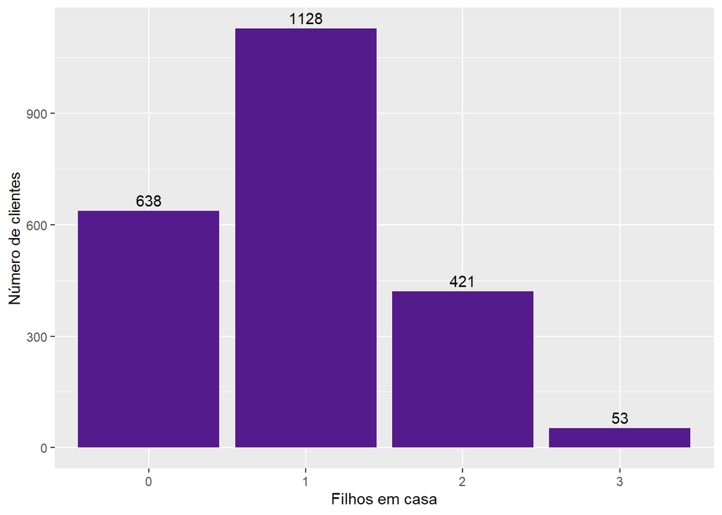

Número de filhos em casa (crianças + adolescentes)

```r
# Contando os clientes por total de filhos em casa (crianças + adolescentes)
filhos_contagem <- clientes_raw |>
  count(filhos = Kidhome + Teenhome)

# Gráfico de barras com a contagem escrita em cima de cada barra
filhos_contagem |>
  ggplot(aes(x = factor(filhos), y = n)) +
  geom_col(fill = "purple4") +
  geom_text(aes(label = n), vjust = -0.4) +
  labs(x = "Filhos em casa", y = "Número de clientes")
```

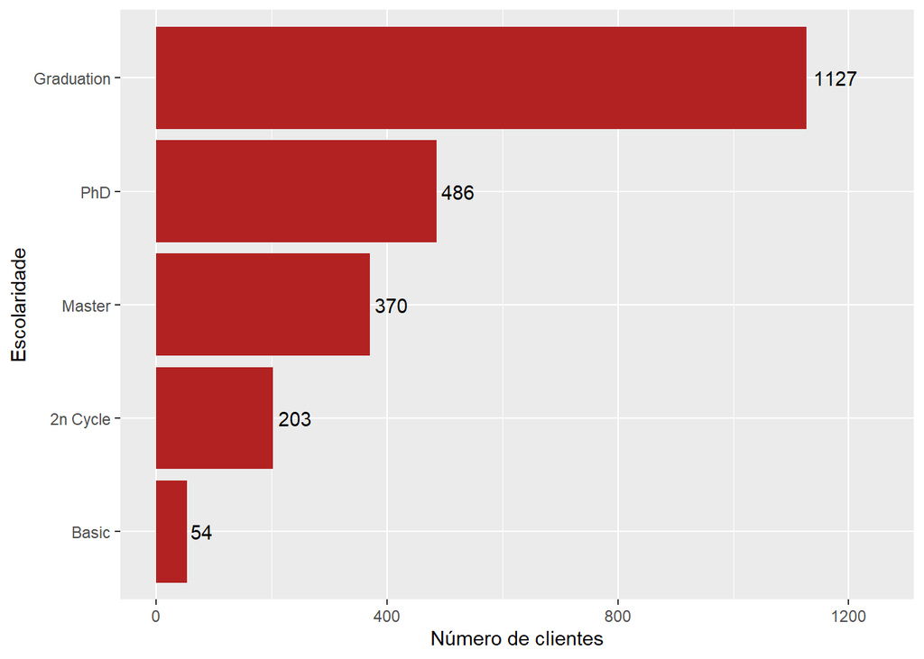

Escolaridade dos clientes

```r
# Contando os clientes por nível de escolaridade (Education)
escolaridade_contagem <- clientes_raw |>
  count(Education)

# Barras ordenadas pela frequência, com a contagem na ponta de cada barra
escolaridade_contagem |>
  ggplot(aes(x = reorder(Education, n), y = n)) +
  geom_col(fill = "firebrick") +
  geom_text(aes(label = n), hjust = -0.15) +
  coord_flip() +
  expand_limits(y = 1250) +
  labs(x = "Escolaridade", y = "Número de clientes")
```

A maioria das famílias tem **1 filho** em casa (1.128 clientes), enquanto 638 clientes não têm nenhum e só 53 têm 3. Quanto à escolaridade, `Graduation` é o nível mais comum (1.127 clientes, metade da base), seguido de `PhD` (486) e `Master` (370). Note que `2n Cycle` (203) e `Master` são provavelmente equivalentes, mas aparecem separados nos dados.

## Estado civil: os dados estão limpos?

**Pergunta do marketing:** *como se distribui o estado civil dos clientes?*

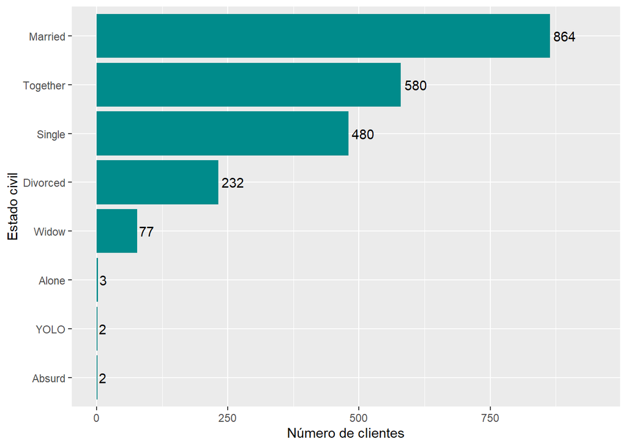

Estado civil dos clientes (como vem nos dados)

```r
# Contando os clientes por estado civil
estado_civil_contagem <- clientes_raw |>
  count(Marital_Status)

# Barras ordenadas pela frequência, com a contagem na ponta de cada barra
estado_civil_contagem |>
  ggplot(aes(x = reorder(Marital_Status, n), y = n)) +
  geom_col(fill = "darkcyan") +
  geom_text(aes(label = n), hjust = -0.15) +
  coord_flip() +
  expand_limits(y = 950) +
  labs(x = "Estado civil", y = "Número de clientes")
```

As categorias comuns são `Married` (864), `Together` (580), `Single` (480), `Divorced` (232) e `Widow` (77). Mas aparecem também **`Alone` (3), `Absurd` (2) e `YOLO` (2)**: rótulos que não são estados civis de verdade (`Alone` equivale a `Single`; `Absurd` e `YOLO` são lixo de digitação). São poucos casos, mas um bom exemplo de que **dados reais precisam de limpeza** antes de qualquer análise.

## O que levamos para a próxima seção

- **Ano de nascimento:** três valores impossíveis (1893, 1899 e 1900).
- **Renda:** um outlier de 666.666 e 24 valores ausentes.
- **Gastos:** distribuição muito assimétrica, o que motiva o uso do logaritmo.
- **Estado civil:** categorias estranhas (`Absurd`, `YOLO`, `Alone`).

Na seção 3 vamos corrigir tudo isso e criar as variáveis que usaremos no agrupamento.

# 3. Preparação dos dados

Os algoritmos de clustering **não sabem** que 1893 é um ano de nascimento impossível, nem que 666.666 é uma renda suspeita: eles tratam qualquer número como verdadeiro. Por isso, antes de agrupar, vamos (1) **limpar** os problemas que vimos na seção 2, (2) **criar variáveis** mais úteis para o negócio, (3) **escolher** quais variáveis entram no agrupamento e (4) **colocá-las na mesma escala**.

## Limpeza dos dados

Cada regra abaixo é um passo separado, e o código mostra quantos clientes sobram em cada um. Assim sabemos exatamente o que foi removido e por quê.

**Passo 1: renda ausente.** O algoritmo precisa de um número para calcular a distância entre clientes; com `NA`, a conta não fecha. Como são só 24 clientes (cerca de 1% da base), vamos **removê-los** em vez de inventar uma renda para eles.

**Passo 2: renda extrema.** O cliente de renda 666.666 está muito isolado dos demais (a seguinte mais alta é 162.397). Ele seria quase um grupo sozinho e distorceria as distâncias. Como corte, usamos **200.000**: fica acima de todas as rendas “normais” e abaixo do ponto suspeito.

**Passo 3: ano de nascimento impossível.** Os anos 1893, 1899 e 1900 (clientes com mais de 110 anos) são provavelmente erros de digitação. Removemos quem nasceu **antes de 1920**; o próximo ano mais antigo da base é 1940.

```r
# 3. Preparação dos dados ----

# Quantos clientes temos antes da limpeza?
nrow(clientes_raw)
```

```
[1] 2240
```

```r
# Passo 1: removendo quem não tem renda informada (NA)
passo1 <- clientes_raw |>
  filter(!is.na(Income))
nrow(passo1)                    # quantos sobraram?
```

```
[1] 2216
```

```r
# Passo 2: removendo a renda extrema (acima de 200.000)
passo2 <- passo1 |>
  filter(Income <= 200000)
nrow(passo2)
```

```
[1] 2215
```

```r
# Passo 3: removendo anos de nascimento impossíveis (antes de 1920)
passo3 <- passo2 |>
  filter(Year_Birth >= 1920)
nrow(passo3)
```

```
[1] 2212
```

Saímos de **2.240** para **2.212** clientes: 24 sem renda, 1 com renda extrema e 3 com ano de nascimento impossível (nenhum dos três tinha `Income` ausente, por isso as contas se somam). Perdemos cerca de 1,2% da base, um custo pequeno para dados bem mais confiáveis.

**Estado civil.** Em vez de 8 categorias (algumas sem sentido), vamos usar só duas: **`"Casado/Junto"`** (`Married` e `Together`, que vivem com um parceiro) e **`"Sozinho"`** (todo o resto: `Single`, `Divorced`, `Widow`, `Alone`, e também `Absurd` e `YOLO`). Agrupar o “resto” é uma decisão simples: os rótulos sem sentido são só 4 clientes, e o que importa para o marketing é haver ou não um parceiro em casa.

**Colunas sem informação.** `Z_CostContact` e `Z_Revenue` têm o mesmo valor para todos os clientes: não distinguem ninguém, então saem.

## Variáveis derivadas

Muitas vezes, uma variável nova é mais útil do que as originais. Vamos criar cinco:

- **`Idade`**: `2014 - Year_Birth`. Usamos 2014 porque é o ano do cadastro mais recente da base (veja `Tempo_casa_dias` abaixo): é como se “hoje” fosse o meio de 2014, e não o ano atual.
- **`Filhos`**: crianças + adolescentes em casa (`Kidhome + Teenhome`).
- **`Gasto_total`**: soma das seis colunas `Mnt*`.
- **`Compras_total`**: soma das compras no site, no catálogo e na loja.
- **`Tempo_casa_dias`**: há quantos dias a pessoa é cliente. A coluna `Dt_Customer` vem como texto no formato dia-mês-ano, então usamos `dmy()` para o R entendê-la como data e contamos os dias até **29/06/2014**, a data de cadastro mais recente da base.

```r
# Aplicando todas as regras de limpeza de uma vez, na mesma sequência dos passos acima
clientes <- clientes_raw |>
  filter(!is.na(Income),            # passo 1: renda informada
         Income <= 200000,          # passo 2: sem renda extrema
         Year_Birth >= 1920) |>     # passo 3: ano de nascimento plausível
  # Agrupando o estado civil em duas categorias
  # (x %in% c(...) pergunta "x é um destes valores?" e responde TRUE ou FALSE)
  mutate(Marital_Status = if_else(Marital_Status %in% c("Married", "Together"),
                                  "Casado/Junto", "Sozinho")) |>
  # Removendo as colunas constantes
  select(-Z_CostContact, -Z_Revenue) |>
  # Criando as variáveis derivadas
  mutate(Idade = 2014 - Year_Birth,
         Filhos = Kidhome + Teenhome,
         Gasto_total = MntWines + MntFruits + MntMeatProducts +
           MntFishProducts + MntSweetProducts + MntGoldProds,
         Compras_total = NumWebPurchases + NumCatalogPurchases + NumStorePurchases,
         # dmy() transforma o texto "dia-mês-ano" em data; a diferença entre datas é em dias
         Tempo_casa_dias = as.numeric(as.Date("2014-06-29") - dmy(Dt_Customer)))

# Conferindo: quantos clientes temos agora?
nrow(clientes)
```

```
[1] 2212
```

```r
# Como ficaram o estado civil e as novas variáveis?
clientes |> count(Marital_Status)
```

```
# A tibble: 2 × 2
  Marital_Status     n
  <chr>          <int>
1 Casado/Junto    1428
2 Sozinho          784
```

```r
clientes |>
  select(Idade, Filhos, Gasto_total, Compras_total, Tempo_casa_dias) |>
  summary()
```

```
     Idade           Filhos        Gasto_total     Compras_total
 Min.   :18.00   Min.   :0.0000   Min.   :   5.0   Min.   : 0.00
 1st Qu.:37.00   1st Qu.:0.0000   1st Qu.:  69.0   1st Qu.: 6.00
 Median :44.00   Median :1.0000   Median : 397.0   Median :12.00
 Mean   :45.09   Mean   :0.9476   Mean   : 607.3   Mean   :12.57
 3rd Qu.:55.00   3rd Qu.:1.0000   3rd Qu.:1048.0   3rd Qu.:18.25
 Max.   :74.00   Max.   :3.0000   Max.   :2525.0   Max.   :32.00
 Tempo_casa_dias
 Min.   :  0.0
 1st Qu.:180.0
 Median :356.0
 Mean   :353.7
 3rd Qu.:529.0
 Max.   :699.0
```

Conferindo os números: `Casado/Junto` tem **1.428** clientes e `Sozinho`, **784**. A `Idade` vai de **18 a 74 anos** (mediana 44), plausível para clientes de varejo. `Tempo_casa_dias` vai de **0 a 699 dias**: o cliente mais novo acabou de entrar e o mais antigo tem quase dois anos de casa.

## Escolhendo as variáveis para agrupar

Que informações devem dizer “quem se parece com quem”? Vamos usar **15 variáveis** que descrevem **comportamento de compra** e **perfil**:

- **Perfil:** `Income`, `Idade`, `Filhos`;
- **Comportamento:** `Recency` (dias desde a última compra), os **seis gastos** `Mnt*` e as compras e visitas por canal (`NumDealsPurchases`, `NumWebPurchases`, `NumCatalogPurchases`, `NumStorePurchases`, `NumWebVisitsMonth`).

Ficam **de fora**:

- **Campanhas e reclamações** (`AcceptedCmp1` a `5`, `Response`, `Complain`): queremos descobrir os grupos pelo **jeito de comprar** e só **depois** testar se eles respondem de forma diferente às campanhas. Se usássemos a resposta para formar os grupos, a validação seria circular.
- **Variáveis categóricas** (`Education`, `Marital_Status`): a distância euclidiana (a “régua” que usaremos) só funciona com números. Elas ficam para a seção 5 (distância de Gower), que lida com dados mistos.
- **Totais** (`Gasto_total`, `Compras_total`): são somas de variáveis que estão na lista, e incluí-los contaria o mesmo comportamento duas vezes. Eles servirão para **descrever** os segmentos depois.
- **`Tempo_casa_dias`**: mede há quanto tempo a pessoa é cliente, e não o seu jeito de comprar nem o seu perfil. Também fica só para **descrever** os segmentos depois.

**ImportanteEssa lista é uma decisão, não uma regra**

Não existe uma lista “certa” de variáveis: escolher o que entra no agrupamento faz parte do **processo de decisão do(a) cientista de dados**, e essa escolha muda os grupos que vão aparecer. As justificativas acima são as **nossas**. Outra pessoa poderia, por exemplo, usar o **gasto total** no lugar dos seis gastos por categoria, deixar os gastos de fora para agrupar só pelo perfil e pelos canais, ou incluir o tempo de casa. O importante é **justificar** a escolha pela pergunta de negócio e **mostrar** o que ela produz.

```r
# Variáveis que entram no agrupamento (somente comportamento e perfil)
vars_cluster <- c("Income", "Idade", "Filhos", "Recency",
                  "MntWines", "MntFruits", "MntMeatProducts",
                  "MntFishProducts", "MntSweetProducts", "MntGoldProds",
                  "NumDealsPurchases", "NumWebPurchases", "NumCatalogPurchases",
                  "NumStorePurchases", "NumWebVisitsMonth")

# Quantas variáveis?
length(vars_cluster)
```

```
[1] 15
```

## Gastos: o logaritmo (`log1p`)

Na seção 2 vimos que os gastos têm cauda longa. Vamos ver o efeito de aplicar o logaritmo, usando `MntWines` como exemplo. Usamos **`log1p(x)`**, que calcula `log(1 + x)`: é o logaritmo “seguro” para gastos que podem ser zero, porque `log(0)` não existe, mas `log1p(0)` vale 0 (há 13 clientes com gasto zero em vinhos). O logaritmo comprime os valores grandes: a diferença entre gastar 1.000 e 1.100 fica muito menor do que a diferença entre gastar 10 e 110.

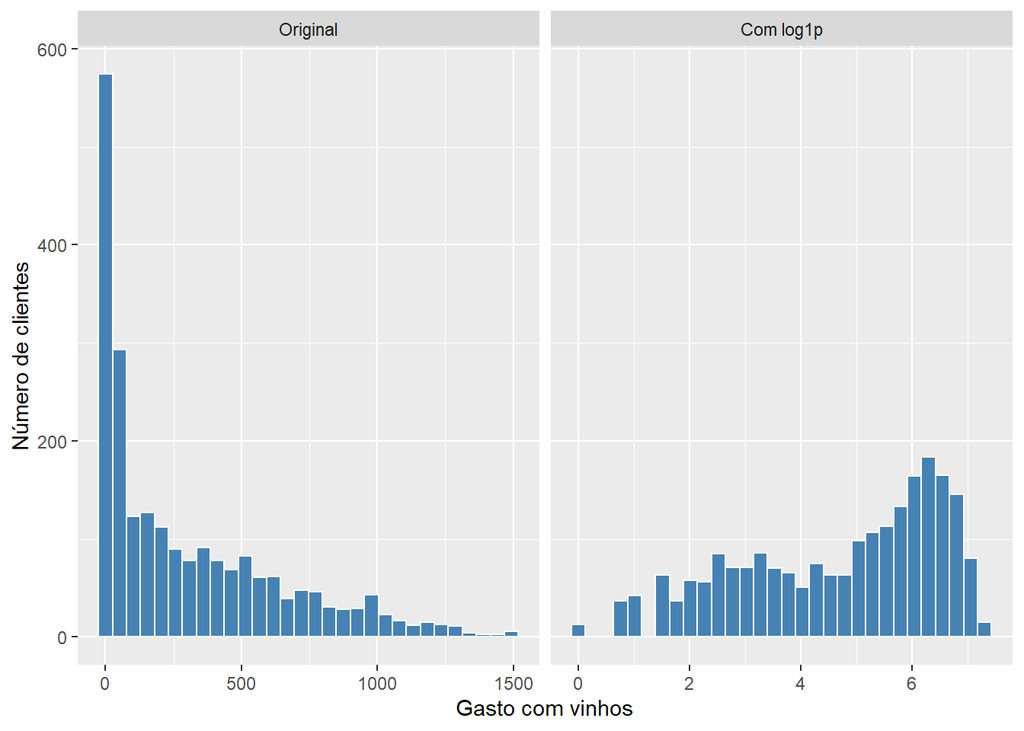

MntWines antes e depois do log1p

```r
# Colocando o gasto original e o gasto em log lado a lado, para comparar
vinhos <- tibble(`Original` = clientes$MntWines,
                 `Com log1p` = log1p(clientes$MntWines)) |>
  pivot_longer(everything(), names_to = "escala", values_to = "valor") |>
  # fixando a ordem dos painéis: original primeiro
  mutate(escala = factor(escala, levels = c("Original", "Com log1p")))

# Dois histogramas, um por escala (cada painel tem seu próprio eixo x)
vinhos |>
  ggplot(aes(x = valor)) +
  geom_histogram(bins = 30, fill = "steelblue", color = "white") +
  facet_wrap(~ escala, scales = "free_x") +
  labs(x = "Gasto com vinhos", y = "Número de clientes")
```

```r
# Média e mediana nas duas escalas
tibble(escala = c("Original", "Com log1p"),
       media = c(mean(clientes$MntWines), mean(log1p(clientes$MntWines))),
       mediana = c(median(clientes$MntWines), median(log1p(clientes$MntWines))))
```

```
# A tibble: 2 × 3
  escala     media mediana
  <chr>      <dbl>   <dbl>
1 Original  305.    176.
2 Com log1p   4.68    5.17
```

No gráfico original, a maioria dos clientes se amontoa à esquerda, com uma cauda longa à direita: a **média (US$ 305,3) é bem maior que a mediana (US$ 175,5)**. Na escala logarítmica, os clientes se espalham de forma mais equilibrada. Ainda sobra uma barra isolada à esquerda: são os clientes com gasto zero. Faremos o mesmo nos seis gastos.

Agora montamos `dados_cluster`: a tabela só com as variáveis escolhidas, com `log1p()` aplicado nas seis colunas `Mnt*`.

```r
# Tabela só com as variáveis do agrupamento; log1p() nas seis colunas que começam com "Mnt"
dados_cluster <- clientes[vars_cluster] |>
  mutate(across(starts_with("Mnt"), log1p))

# Conferindo: uma linha por cliente, 15 colunas, nenhum NA
dim(dados_cluster)
```

```
[1] 2212   15
```

```r
anyNA(dados_cluster)
```

```
[1] FALSE
```

Como fizemos com os vinhos, vamos ver o “antes e depois” dos **seis gastos**. Cada linha da figura tem dois gastos; para cada um, o painel da esquerda é o original e o da direita, com `log1p`.

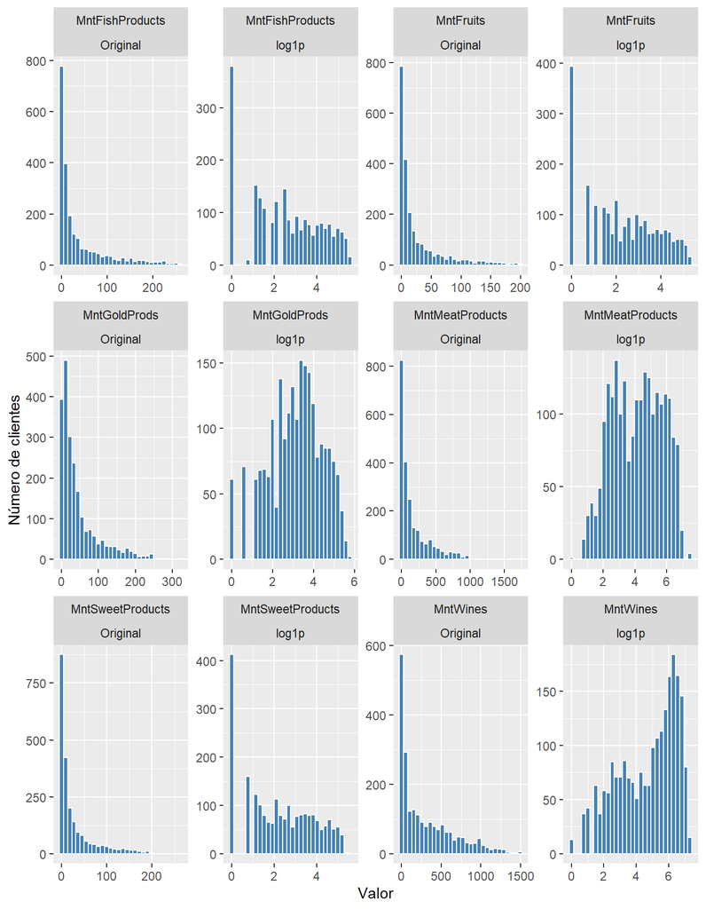

Os seis gastos antes (Original) e depois (log1p) da transformação

```r
# Juntando, para cada gasto, os valores originais (clientes) e com log1p (dados_cluster)
gastos_antes_depois <- bind_rows(
  clientes |> select(starts_with("Mnt")) |> mutate(escala = "Original"),
  dados_cluster |> select(starts_with("Mnt")) |> mutate(escala = "log1p")
) |>
  pivot_longer(-escala, names_to = "gasto", values_to = "valor") |>
  mutate(escala = factor(escala, levels = c("Original", "log1p")))

# Um histograma por gasto e escala (cada painel com seus próprios eixos)
gastos_antes_depois |>
  ggplot(aes(x = valor)) +
  geom_histogram(bins = 30, fill = "steelblue", color = "white") +
  facet_wrap(gasto ~ escala, scales = "free", ncol = 4) +
  labs(x = "Valor", y = "Número de clientes")
```

Nos seis gastos, o original tem o mesmo formato dos vinhos: uma “parede” de clientes perto de zero e uma cauda longa à direita. Com o `log1p`, os clientes que gastam alguma coisa se espalham bem melhor. A barra isolada à esquerda são os clientes que **não gastaram nada** naquela categoria: em carnes, vinhos e produtos “ouro” eles são poucos, mas em **frutas, peixes e doces** são cerca de 400 clientes. O log não “inventa” diferenças entre eles: quem gastou zero continua empatado em zero.

## Por que padronizar? Um experimento

As variáveis estão em **unidades muito diferentes**: `Income` está na casa das dezenas de milhares, e `Filhos` vai de 0 a 3. O clustering usa a **distância entre clientes** (o “Pitágoras” generalizado: somamos os quadrados das diferenças em cada variável e tiramos a raiz), então uma variável com números grandes pode “mandar sozinha” na distância. Primeiro, o desvio-padrão (o quanto cada variável varia) de cada uma:

```r
# Desvio-padrão de cada variável, em ordem decrescente
sapply(dados_cluster, sd) |>
  round(2) |>
  sort(decreasing = TRUE)
```

```
             Income             Recency               Idade   NumStorePurchases
           21527.28               28.94               11.70                3.25
NumCatalogPurchases     NumWebPurchases   NumWebVisitsMonth   NumDealsPurchases
               2.93                2.74                2.43                1.92
           MntWines     MntFishProducts    MntSweetProducts           MntFruits
               1.80                1.66                1.59                1.57
    MntMeatProducts        MntGoldProds              Filhos
               1.56                1.29                0.75
```

O desvio-padrão de `Income` (**US$ 21.527**) é mais de 700 vezes o da segunda variável que mais varia (`Recency`, 28,94). Vamos ver o efeito. Escolhemos um cliente (o primeiro da base) e procuramos os **3 clientes mais parecidos com ele**, de dois jeitos: com os dados **sem padronizar** e com os dados **padronizados** (`scale()`, que explicamos logo depois). A tabela mostra a distância de cada vizinho e `pct_income`, a **porcentagem da distância ao quadrado que vem só de `Income`**.

```r
# Padronizando: scale() subtrai a média e divide pelo desvio-padrão de cada coluna.
# Depois disso, cada variável tem média 0 e desvio-padrão 1 (guardamos o resultado em dados_pad)
dados_pad <- scale(dados_cluster)

# Função que acha os 3 vizinhos mais próximos do cliente 1 em uma matriz de dados
tres_vizinhos <- function(m) {
  # Diferença de cada cliente para o cliente 1, variável por variável
  dif <- sweep(m, 2, m[1, ])
  # Distância = raiz da soma dos quadrados das diferenças
  distancia <- sqrt(rowSums(dif^2))
  # Posições dos 3 mais próximos (a posição 1 é o próprio cliente, com distância 0)
  viz <- order(distancia)[2:4]
  # Tabela: quem são, quão longe estão e quanto da distância vem de Income
  tibble(vizinho = viz,
         distancia = round(distancia[viz], 2),
         pct_income = round(100 * dif[viz, "Income"]^2 / rowSums(dif[viz, ]^2), 1)) |>
    bind_cols(clientes[viz, c("Income", "Idade", "Filhos", "Gasto_total")])
}

# O cliente 1 (a referência)
clientes[1, c("Income", "Idade", "Filhos", "Gasto_total")]
```

```
# A tibble: 1 × 4
  Income Idade Filhos Gasto_total
   <dbl> <dbl>  <dbl>       <dbl>
1  58138    57      0        1617
```

```r
# Vizinhos SEM padronizar
tres_vizinhos(as.matrix(dados_cluster))
```

```
# A tibble: 3 × 7
  vizinho distancia pct_income Income Idade Filhos Gasto_total
    <int>     <dbl>      <dbl>  <dbl> <dbl>  <dbl>       <dbl>
1    1186      27.9       80.4  58113    55      1         758
2    1970      32         47.3  58116    58      1         443
3    1725      58.8       78.1  58086    45      1         792
```

```r
# Vizinhos COM padronização
tres_vizinhos(dados_pad)
```

```
# A tibble: 3 × 7
  vizinho distancia pct_income Income Idade Filhos Gasto_total
    <int>     <dbl>      <dbl>  <dbl> <dbl>  <dbl>       <dbl>
1    2135      2.23        0.3  60896    50      1        1701
2      38      2.31        3.4  48948    71      0         902
3     879      2.31        3.4  48948    71      0         902
```

**Sem padronizar**, os três “vizinhos mais próximos” têm renda quase idêntica à do cliente de referência (US$ 58.113, US$ 58.116 e US$ 58.086, contra US$ 58.138), mas são **bem diferentes no resto**: o cliente 1 gastou US$ 1.617 no total, e os vizinhos gastaram US$ 758, US$ 443 e US$ 792. `Income` responde por **80,4%, 47,3% e 78,1%** da distância ao quadrado: uma única variável, entre 15, decide quase metade ou mais da distância. **Padronizando**, os vizinhos são outros (posições 2135, 38 e 879), com rendas entre US$ 48.948 e US$ 60.896, mas mais parecidos no conjunto das 15 variáveis (no gasto, por exemplo: todos gastam mais de US$ 900 no total), embora a idade agora varie mais (71 anos nos dois últimos, contra 57 do cliente de referência; sem padronizar, eram 55, 58 e 45). `Income` cai para **0,3% a 3,4%** da distância: agora cada variável tem voz. Repare que os dois últimos vizinhos (IDs 2968 e 8800) têm exatamente os mesmos valores nas 15 variáveis (distância igual): provavelmente é um registro duplicado na base.

## Padronização (z-score)

O que o `scale()` faz é o **z-score**: para cada valor, subtrai-se a média da coluna e divide-se pelo desvio-padrão. Para o valor $x_i$ do cliente $i$ numa variável com média $\bar{x}$ e desvio-padrão $s$:

$$z_i = \frac{x_i - \bar{x}}{s}$$

O resultado diz “**quantos desvios-padrão** este cliente está acima ou abaixo da média”: 0 é um cliente na média, +1 é um desvio acima, −2 são dois abaixo. Como toda variável passa a ter média 0 e desvio-padrão 1, **todas valem igual** na distância.

O z-score não é a única padronização. Outra muito usada é a **min-max**, que leva cada variável para o intervalo de 0 a 1 (0 = o menor valor da base, 1 = o maior):

$$x_i' = \frac{x_i - \min(x)}{\max(x) - \min(x)}$$

A min-max é fácil de ler, mas é sensível a valores extremos: um único cliente muito fora do padrão define o máximo e “espreme” todos os outros perto de zero (mais um motivo para o log nos gastos e para a limpeza da renda). Ela vai reaparecer na seção 5, dentro da distância de Gower. Nesta aula, usamos o z-score.

```r
# Conferindo: toda coluna deve ter média 0 (arredondada) e desvio-padrão 1
round(colMeans(dados_pad), 4)
```

```
             Income               Idade              Filhos             Recency
                  0                   0                   0                   0
           MntWines           MntFruits     MntMeatProducts     MntFishProducts
                  0                   0                   0                   0
   MntSweetProducts        MntGoldProds   NumDealsPurchases     NumWebPurchases
                  0                   0                   0                   0
NumCatalogPurchases   NumStorePurchases   NumWebVisitsMonth
                  0                   0                   0
```

```r
apply(dados_pad, 2, sd)
```

```
             Income               Idade              Filhos             Recency
                  1                   1                   1                   1
           MntWines           MntFruits     MntMeatProducts     MntFishProducts
                  1                   1                   1                   1
   MntSweetProducts        MntGoldProds   NumDealsPurchases     NumWebPurchases
                  1                   1                   1                   1
NumCatalogPurchases   NumStorePurchases   NumWebVisitsMonth
                  1                   1                   1
```

```r
# Dimensão final da matriz que usaremos nas próximas seções
dim(dados_pad)
```

```
[1] 2212   15
```

As 15 médias são 0 e os 15 desvios-padrão são 1, como esperado. A matriz `dados_pad` (**2.212 clientes × 15 variáveis**, já limpa, com log nos gastos e padronizada) é a base das próximas seções.

## Uma última olhada: as variáveis duas a duas

Antes de agrupar, vale olhar as 15 variáveis padronizadas **duas a duas**. Com 15 variáveis são 105 pares, e um gráfico só com todos eles fica pequeno demais para ler. Por isso, dividimos a olhada em **abas** (clique no nome de cada aba para trocar de gráfico):

- **Visão geral:** a **correlação** de todos os pares num mapa de calor (de −1 a 1; azul = sobem juntos, vermelho = um sobe quando o outro desce);
- **Perfil**, **Gastos** e **Canais:** uma **matriz de gráficos de dispersão** para cada bloco de variáveis. Abaixo da diagonal, os pontos (um por cliente); acima, a correlação do par (o número fica maior quanto mais forte a relação);
- **Renda × demais:** a renda, a variável de perfil mais ligada ao comportamento, contra cada uma das outras.

```r
# Funções auxiliares para as matrizes de dispersão das abas abaixo

# Painel de cima: escreve a correlação do par, com tamanho proporcional à sua força
painel_correlacao <- function(x, y, ...) {
  r <- cor(x, y)
  usr <- par("usr"); on.exit(par(usr = usr))
  par(usr = c(0, 1, 0, 1))
  text(0.5, 0.5, sprintf("%.2f", r), cex = 1 + 2 * abs(r),
       col = if (r > 0) "steelblue" else "firebrick")
}

# Painel de baixo: um ponto semitransparente por cliente
painel_pontos <- function(x, y, ...) {
  points(x, y, pch = 16, cex = 0.4, col = rgb(0.27, 0.51, 0.71, 0.25))
}

# Matriz de dispersão de um bloco de colunas de dados_pad
# (nomes encurtados para caberem na diagonal, ex.: "MntSweetProducts" vira "MntSweet")
matriz_dispersao <- function(colunas) {
  rotulos <- sub("(Purchases|Products|Prods)$", "", colunas)
  pairs(dados_pad[, colunas], labels = rotulos,
        lower.panel = painel_pontos, upper.panel = painel_correlacao,
        cex.labels = 1.1, gap = 0.4)
}
```

**Visão geral**

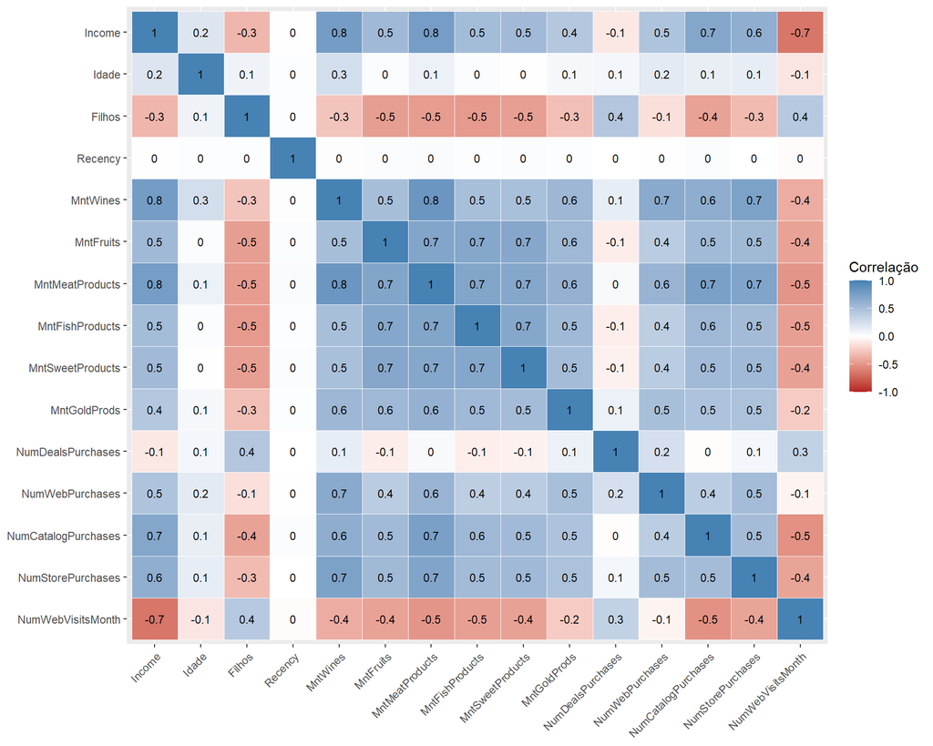

Correlação entre as 15 variáveis padronizadas

```r
# Matriz de correlações em formato longo (uma linha por par de variáveis)
correlacoes <- cor(dados_pad) |>
  as.data.frame() |>
  rownames_to_column("var1") |>
  pivot_longer(-var1, names_to = "var2", values_to = "correlacao") |>
  # mantém a ordem original das variáveis nos eixos
  mutate(var1 = factor(var1, levels = colnames(dados_pad)),
         var2 = factor(var2, levels = rev(colnames(dados_pad))))

# Mapa de calor das correlações, com o valor escrito em cada casa
correlacoes |>
  ggplot(aes(x = var1, y = var2, fill = correlacao)) +
  geom_tile(color = "white") +
  geom_text(aes(label = round(correlacao, 1)), size = 3) +
  scale_fill_gradient2(low = "firebrick", mid = "white", high = "steelblue",
                       midpoint = 0, limits = c(-1, 1)) +
  labs(x = NULL, y = NULL, fill = "Correlação") +
  theme(axis.text.x = element_text(angle = 45, hjust = 1))
```

**Perfil**

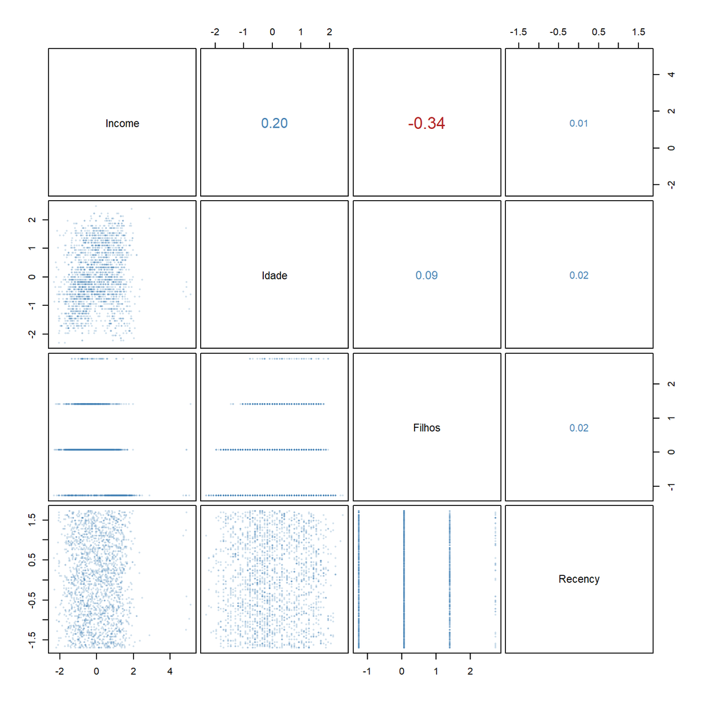

Variáveis de perfil, duas a duas

```r
matriz_dispersao(c("Income", "Idade", "Filhos", "Recency"))
```

**Gastos**

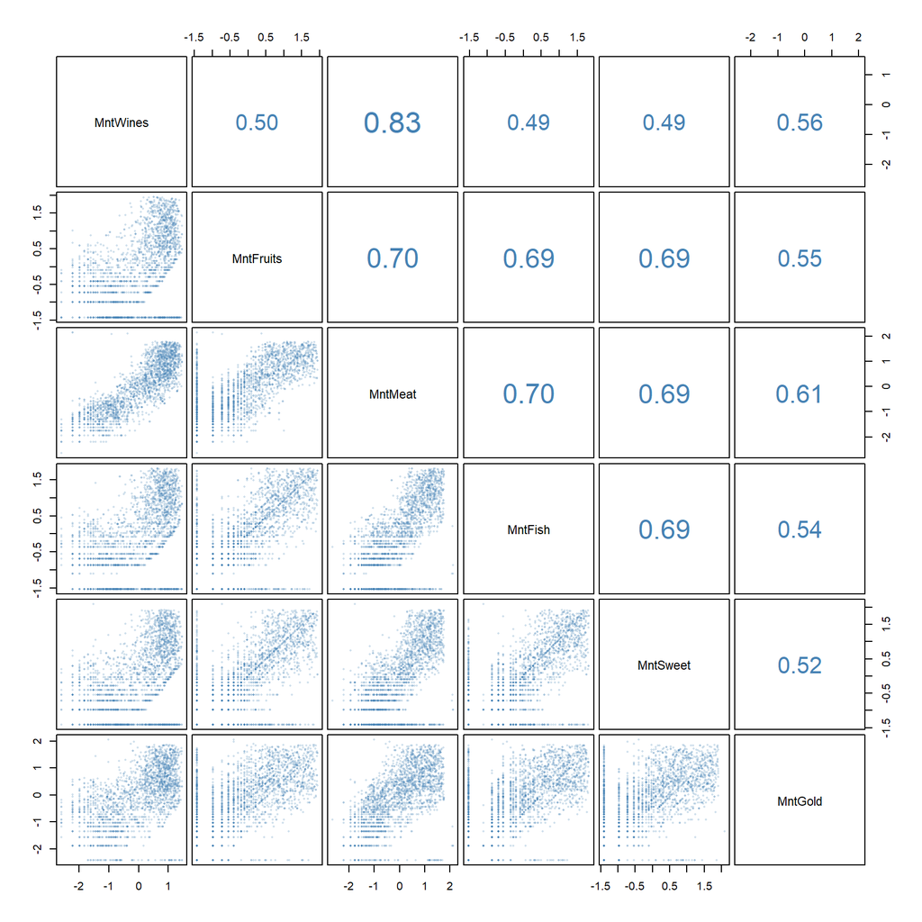

Os seis gastos (com log1p), dois a dois

```r
matriz_dispersao(c("MntWines", "MntFruits", "MntMeatProducts",
                   "MntFishProducts", "MntSweetProducts", "MntGoldProds"))
```

**Canais**

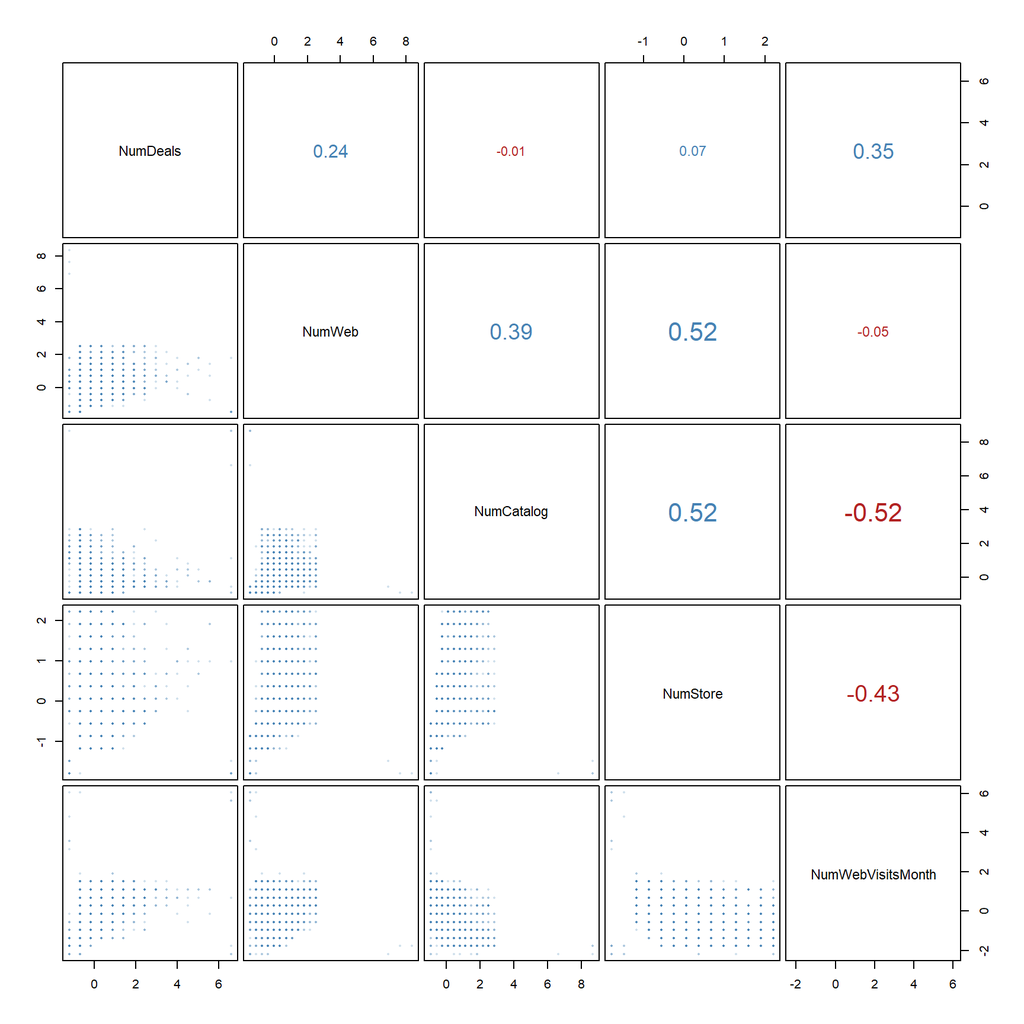

Compras e visitas por canal, duas a duas

```r
matriz_dispersao(c("NumDealsPurchases", "NumWebPurchases", "NumCatalogPurchases",
                   "NumStorePurchases", "NumWebVisitsMonth"))
```

**Renda × demais**

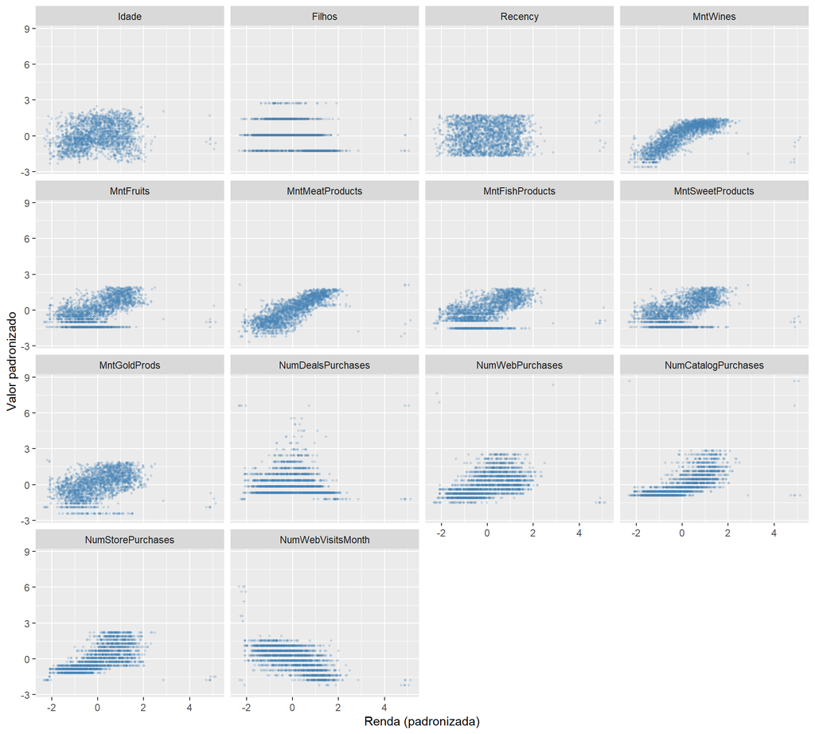

Renda (padronizada) contra cada uma das outras 14 variáveis

```r
# Renda no eixo x; cada painel tem outra variável no eixo y
as_tibble(dados_pad) |>
  pivot_longer(-Income, names_to = "variavel", values_to = "valor") |>
  mutate(variavel = factor(variavel, levels = colnames(dados_pad)[-1])) |>
  ggplot(aes(x = Income, y = valor)) +
  geom_point(alpha = 0.2, size = 0.7, color = "steelblue") +
  facet_wrap(~ variavel, ncol = 4) +
  labs(x = "Renda (padronizada)", y = "Valor padronizado")
```

Os **gastos** (`Mnt*`), a **renda** e as compras no catálogo e na loja formam um “bloco” de correlações positivas fortes (azul na visão geral): é o comportamento “gasta muito” aparecendo em várias variáveis ao mesmo tempo. `Filhos` e `NumWebVisitsMonth` andam no sentido contrário (vermelho). `Idade` e `Recency` quase não se relacionam com nada (casas brancas). Repare também, nas abas de dispersão, que **nenhum par mostra “nuvens” separadas**: os pontos formam massas contínuas, sem grupos visíveis a olho nu. Os grupos, se existirem, estão nas 15 dimensões juntas, e é isso que o clustering vai procurar.

# 4. Cluster hierárquico

Agora sim vamos agrupar. Tudo o que faremos parte da mesma pergunta: **quão longe um cliente está do outro?** Clientes “perto” devem cair no mesmo grupo; clientes “longe”, em grupos diferentes.

## Distância entre clientes e a matriz de distâncias

A **distância euclidiana** é a régua que já usamos na seção 3: para dois clientes, calculamos a diferença em cada uma das 15 variáveis padronizadas, elevamos ao quadrado, somamos e tiramos a raiz (o “Pitágoras” com 15 lados). A função `dist()` faz essa conta para **todos os pares de clientes** de uma vez e guarda o resultado numa **matriz de distâncias**: uma tabela em que a linha *i* e a coluna *j* dizem a distância entre o cliente *i* e o cliente *j*.

Para enxergar a ideia, começamos com um exemplo de brinquedo: **6 clientes** com só **2 variáveis** (renda e gasto, numa escala de 0 a 10), para que caibam num gráfico. Com 2 variáveis, a distância entre dois clientes é o comprimento da linha reta que os liga:

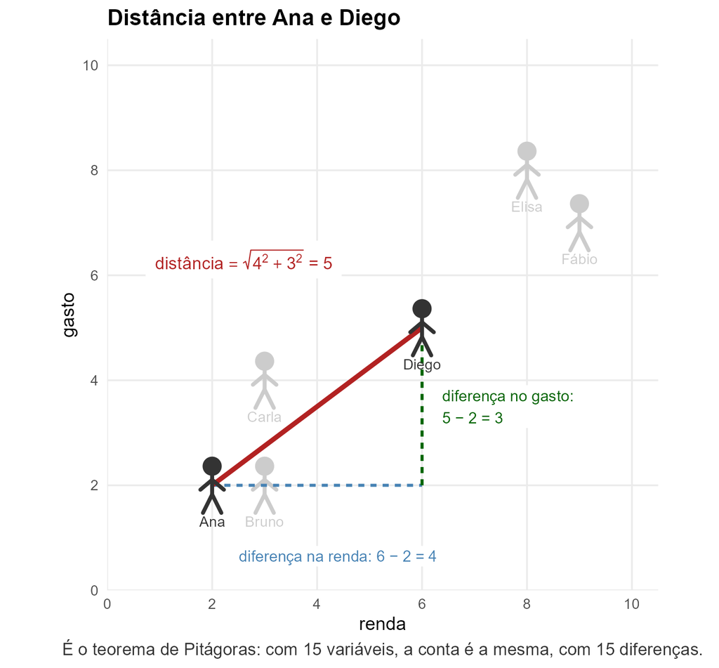

A distância entre Ana e Diego é a hipotenusa de um triângulo retângulo: 4 de diferença na renda e 3 no gasto dão distância 5.

Fazendo essa conta para **todos os pares** (com 6 clientes, são 15 pares), montamos a **matriz de distâncias**:

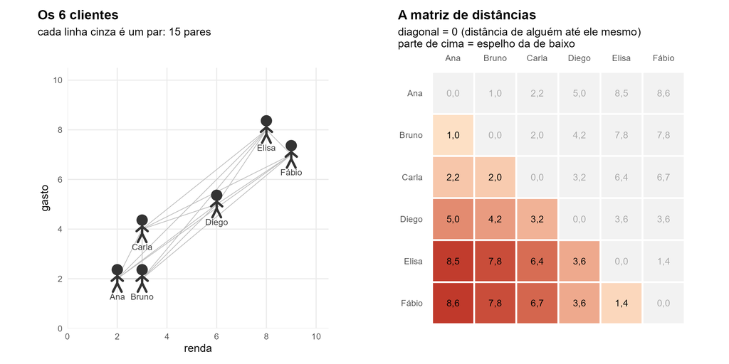

Os 6 clientes e a matriz de distâncias entre eles

Vamos montar o mesmo exemplo no R e pedir a matriz com `dist()`:

```r
# 4. Cluster hierárquico ----

# Exemplo de brinquedo: 6 clientes com 2 variáveis (renda e gasto, de 0 a 10)
exemplo <- tibble(
  nome  = c("Ana", "Bruno", "Carla", "Diego", "Elisa", "Fábio"),
  renda = c(2, 3, 3, 6, 8, 9),
  gasto = c(2, 2, 4, 5, 8, 7)
)
exemplo
```

```
# A tibble: 6 × 3
  nome  renda gasto
  <chr> <dbl> <dbl>
1 Ana       2     2
2 Bruno     3     2
3 Carla     3     4
4 Diego     6     5
5 Elisa     8     8
6 Fábio     9     7
```

```r
# Matriz só com as duas variáveis, com o nome de cada cliente nas linhas
m_exemplo <- as.matrix(exemplo[, c("renda", "gasto")])
rownames(m_exemplo) <- exemplo$nome

# Matriz de distâncias dos 6 clientes (arredondada em 1 casa)
dist_exemplo <- dist(m_exemplo)
round(dist_exemplo, 1)
```

```
      Ana Bruno Carla Diego Elisa
Bruno 1.0
Carla 2.2   2.0
Diego 5.0   4.2   3.2
Elisa 8.5   7.8   6.4   3.6
Fábio 8.6   7.8   6.7   3.6   1.4
```

Os números são os da figura: Ana e Diego estão a **5,0**, Ana e Bruno (os mais próximos) a **1,0**. Com os clientes de verdade, a conta é a mesma, só que com 15 variáveis em vez de 2. Vamos ver com só **3 clientes** antes de usar a base inteira.

```r
# Matriz de distâncias de apenas 3 clientes (as 3 primeiras linhas de dados_pad)
dist(dados_pad[1:3, ]) |> round(2)
```

```
     1    2
2 7.70
3 4.22 6.58
```

```r
# Conferindo à mão a distância entre o cliente 1 e o cliente 2:
# diferença em cada variável, ao quadrado, somada, e a raiz
sqrt(sum((dados_pad[1, ] - dados_pad[2, ])^2)) |> round(2)
```

```
[1] 7.7
```

A saída mostra só a “metade de baixo” da tabela, porque a distância de 1 até 2 é a mesma de 2 até 1, e a distância de um cliente até ele mesmo é 0. A conta “à mão” bate com o valor da linha 2, coluna 1. Agora, a matriz para todos os clientes:

```r
# Matriz de distâncias euclidianas entre TODOS os pares de clientes
dist_euc <- dist(dados_pad)

# Quantas distâncias foram calculadas? (um número para cada par de clientes)
length(dist_euc)
```

```
[1] 2445366
```

São **2.445.366 distâncias** (2.212 × 2.211 / 2 pares). Por isso o clustering hierárquico fica pesado em bases muito grandes: o número de pares cresce muito rápido com o número de clientes.

## Como juntar dois grupos? Quatro regras

O cluster **hierárquico aglomerativo** começa com **cada cliente sozinho no seu próprio grupo** e, a cada passo, **junta os dois grupos mais próximos**, até sobrar um grupo só com todo mundo. Enquanto cada grupo tem um cliente só, “os mais próximos” é fácil: é a menor distância da matriz. Mas quando um grupo já tem vários clientes, **qual é a distância entre dois grupos?** Há várias regras para responder, chamadas de **ligações**. Veja a construção da árvore com os 6 clientes:

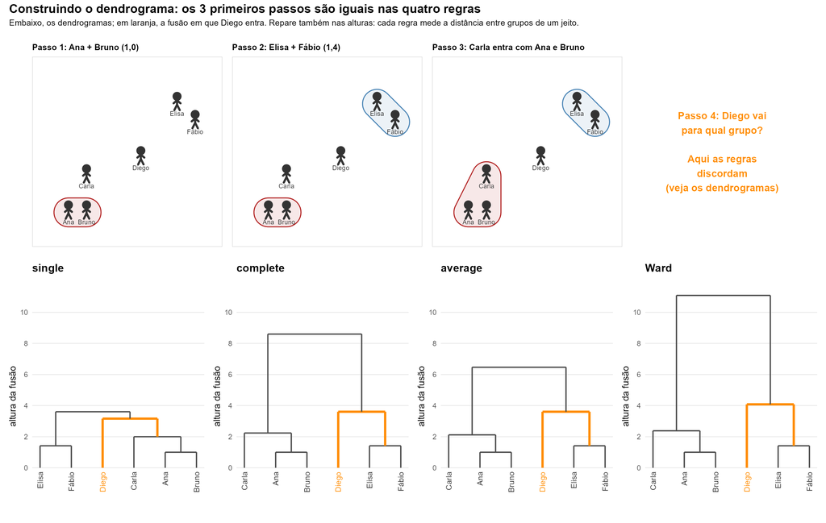

Os passos do agrupamento hierárquico com os 6 clientes e os dendrogramas das quatro regras

Nos três primeiros passos, as quatro regras concordam: Ana e Bruno são os mais próximos (1,0), depois Elisa e Fábio (1,4), e Carla entra no grupo de Ana e Bruno. No passo 4, a pergunta é: **Diego, que está no meio do caminho, vai para qual grupo?** Aqui as regras discordam:

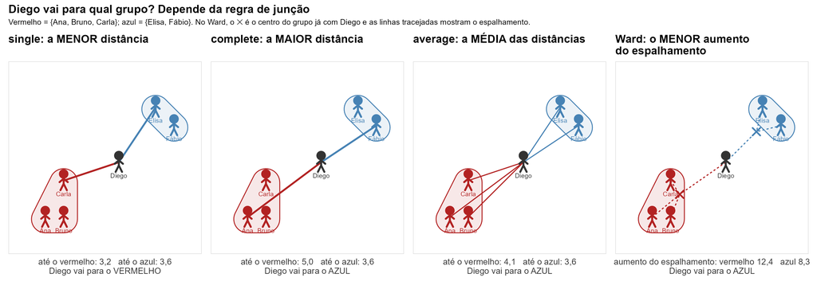

A regra de cada ligação para decidir o grupo de Diego

- **single** (ligação simples): a distância entre dois grupos é a **menor** distância entre um cliente de um grupo e um cliente do outro (os “vizinhos mais próximos”). Diego está a 3,2 de Carla e a 3,6 de Elisa e de Fábio, então vai para o grupo vermelho (Ana, Bruno e Carla).
- **complete** (ligação completa): é a **maior** distância entre os clientes dos dois grupos. Até o grupo vermelho, a maior é 5,0 (até Ana); até o azul, 3,6. Diego vai para o azul (Elisa e Fábio).
- **average** (ligação média): é a **média** de todas as distâncias entre os clientes dos dois grupos. Até o vermelho, a média é 4,1; até o azul, 3,6. Diego vai para o azul.
- **Ward**: não compara distâncias entre pares de clientes. Mede o **espalhamento** de cada grupo (a soma das distâncias ao quadrado de cada cliente até o centro do grupo, o “cliente médio”, marcado com ✕) e escolhe **a fusão que menos aumenta o espalhamento**. Juntar Diego ao vermelho aumenta o espalhamento em 12,4; ao azul, em 8,3. Diego vai para o azul. (O dendrograma do Ward usa uma escala diferente para as alturas, então esses números não aparecem nele como estão.)

**NotaAverage e Ward: quando eles discordam?**

No exemplo, average e Ward concordaram. Mas eles podem discordar, e a diferença está no **tamanho dos grupos**. A average olha só para a distância média entre os clientes dos dois grupos, não importa quantos sejam. Já o Ward mede quanto a fusão aumenta o espalhamento, e esse aumento, para juntar os grupos $A$ e $B$ (com $n_A$ e $n_B$ clientes e centros $\bar{c}_A$ e $\bar{c}_B$), é:

$$\Delta(A, B) = \frac{n_A \cdot n_B}{n_A + n_B} \, \lVert \bar{c}_A - \bar{c}_B \rVert^2$$

ou seja, a distância (ao quadrado) entre os centros, **multiplicada** pelo fator $\frac{n_A \cdot n_B}{n_A + n_B}$, que cresce com o tamanho dos grupos. Por isso, o Ward **“penaliza” a fusão de grupos grandes**. Se dois grupos grandes estiverem relativamente próximos, o Ward pode **adiar** a fusão deles e preferir unir dois grupos pequenos que estão um pouco mais distantes, porque isso aumenta menos o espalhamento total. A average, que não olha para o tamanho, juntaria primeiro os dois grupos grandes. É esse “freio” nos grupos grandes que faz o Ward produzir grupos de tamanhos mais equilibrados, como veremos na base real.

A matriz de distâncias é a mesma; só muda a regra, e já no passo 4 a árvore é outra. Conferindo no R:

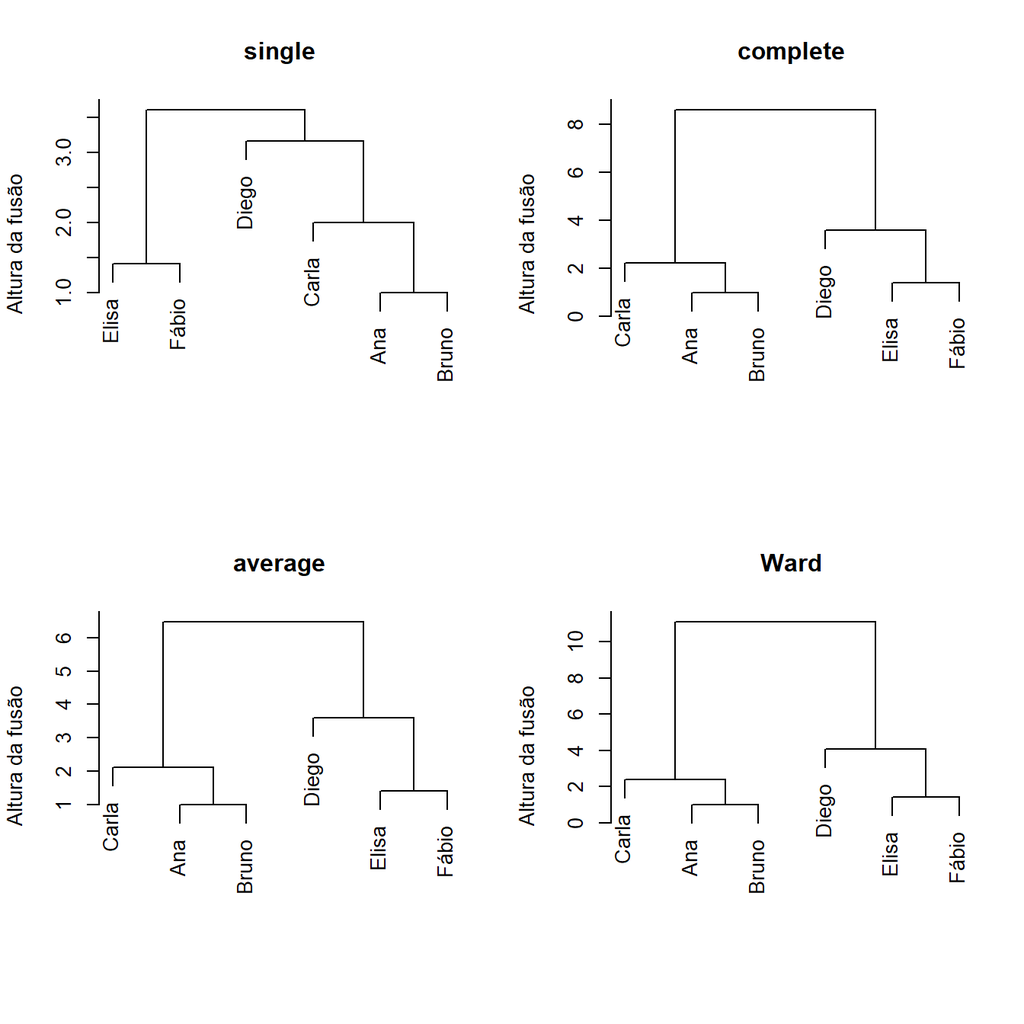

Dendrogramas dos 6 clientes com as quatro regras de ligação

```r
# As quatro regras de ligação aplicadas aos 6 clientes
hc_exemplo <- list(
  single   = hclust(dist_exemplo, method = "single"),
  complete = hclust(dist_exemplo, method = "complete"),
  average  = hclust(dist_exemplo, method = "average"),
  ward     = hclust(dist_exemplo, method = "ward.D2")
)

# Os quatro dendrogramas na mesma janela (dividida em 2 linhas e 2 colunas)
par(mfrow = c(2, 2))
plot(hc_exemplo$single,   main = "single",   xlab = "", sub = "", ylab = "Altura da fusão")
plot(hc_exemplo$complete, main = "complete", xlab = "", sub = "", ylab = "Altura da fusão")
plot(hc_exemplo$average,  main = "average",  xlab = "", sub = "", ylab = "Altura da fusão")
plot(hc_exemplo$ward,     main = "Ward",     xlab = "", sub = "", ylab = "Altura da fusão")
```

```r
par(mfrow = c(1, 1))   # volta a janela gráfica ao normal
```

No single, Diego entra no ramo de Ana, Bruno e Carla; nas outras três regras, no ramo de Elisa e Fábio. Repare também nas **alturas**: como cada regra mede a distância entre grupos de um jeito, as alturas das fusões mudam de uma regra para outra (a última fusão fica a 3,6 no single, 8,6 no complete, 6,5 no average e 11,1 no Ward).

## E na base real?

Agora, as três primeiras regras nos 2.212 clientes (a mesma `dist_euc`), cortando cada árvore em 3 grupos:

```r
# As três ligações "intuitivas" na base real
hc_single   <- hclust(dist_euc, method = "single")
hc_complete <- hclust(dist_euc, method = "complete")
hc_average  <- hclust(dist_euc, method = "average")

# Tamanhos dos grupos quando cortamos cada árvore em 3 grupos
table(cutree(hc_single, k = 3))
```

```
   1    2    3
2208    3    1
```

```r
table(cutree(hc_complete, k = 3))
```

```
   1    2    3
2199    9    4
```

```r
table(cutree(hc_average, k = 3))
```

```
   1    2    3
2205    4    3
```

**O resultado é decepcionante.** Com a single, os grupos têm **2.208**, **3** e **1** cliente; com a complete, **2.199**, **9** e **4**; com a average, **2.205**, **4** e **3**. Em vez de dividir a base, as três regras deixam quase todo mundo num grupo só e separam poucos clientes (de 4 a 13) muito diferentes dos demais. O motivo é que esta base **não tem grupos bem separados**: os clientes formam um contínuo, sem “vazios” entre eles (veremos isso no mapa da seção 6). A single sofre com o **encadeamento**: num contínuo, sempre há um vizinho próximo ligando um cliente ao seguinte, e tudo acaba num grupo só. A complete e a average não encadeiam, mas aqui os poucos clientes muito isolados ficam para as últimas fusões e acabam virando “grupos” quase vazios. Para o marketing, isso não serve: precisamos de uma regra que forme grupos compactos e de tamanhos úteis. Os dendrogramas dessas três regras na base real, que vamos desenhar ao lado do dendrograma do Ward logo adiante, deixam isso bem visível.

## A ligação de Ward

É aqui que entra o **Ward**, a quarta regra da figura: em cada passo, ele junta os dois grupos cuja fusão **menos aumenta o espalhamento** em volta dos centros. Assim, evita fusões que criariam grupos grandes e espalhados e prefere formar **grupos compactos**, que é o que queremos para segmentar. Em R, é o `method = "ward.D2"` (a versão de Ward que trabalha com as distâncias euclidianas como elas são).

```r
# Clustering hierárquico com a ligação de Ward, a partir da matriz de distâncias
hc_ward <- hclust(dist_euc, method = "ward.D2")

# O resultado guarda a sequência de fusões; conferindo o método usado
hc_ward$method
```

```
[1] "ward.D2"
```

## O dendrograma

O histórico das fusões é desenhado num **dendrograma** (uma “árvore”). Na base ficam os 2.212 clientes; subindo, as linhas se juntam sempre que dois grupos se fundem. A **altura** de cada junção mostra o quanto aquela fusão “custou”: junções altas unem grupos **muito diferentes**. Com 2.212 clientes, os nomes na base seriam um borrão preto, então não mostramos os rótulos.

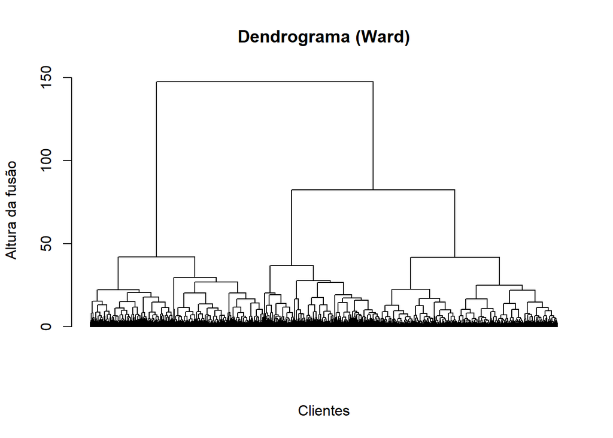

Dendrograma (ligação de Ward) dos 2.212 clientes

```r
# Desenhando o dendrograma sem os rótulos dos clientes (labels = FALSE)
# hang = -1 alinha todos os clientes na base do gráfico
plot(hc_ward, labels = FALSE, hang = -1,
     main = "Dendrograma (Ward)", xlab = "Clientes", sub = "",
     ylab = "Altura da fusão")
```

Compare com as outras três regras na **mesma base** (a mesma `dist_euc`):

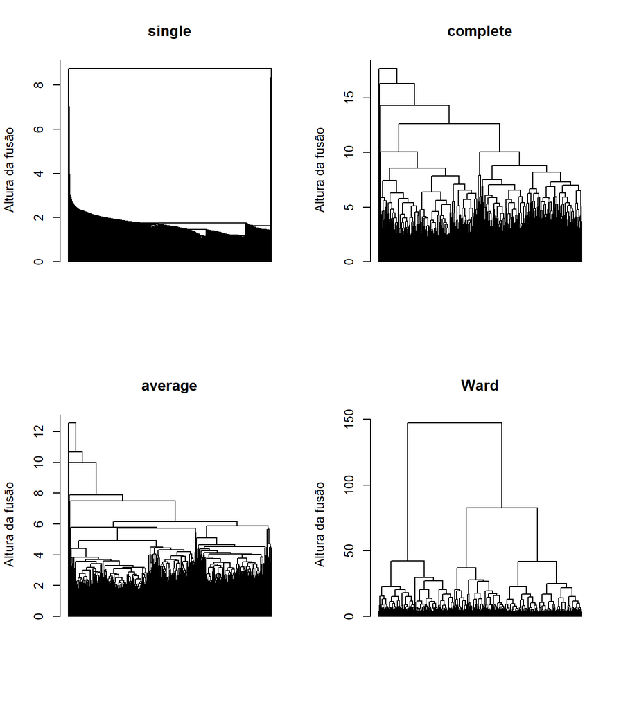

Dendrogramas dos 2.212 clientes com as quatro regras de ligação

```r
# Os quatro dendrogramas da base real lado a lado (2 linhas x 2 colunas)
par(mfrow = c(2, 2))
plot(hc_single,   labels = FALSE, hang = -1, main = "single",   xlab = "", sub = "", ylab = "Altura da fusão")
plot(hc_complete, labels = FALSE, hang = -1, main = "complete", xlab = "", sub = "", ylab = "Altura da fusão")
plot(hc_average,  labels = FALSE, hang = -1, main = "average",  xlab = "", sub = "", ylab = "Altura da fusão")
plot(hc_ward,     labels = FALSE, hang = -1, main = "Ward",     xlab = "", sub = "", ylab = "Altura da fusão")
```

```r
par(mfrow = c(1, 1))
```

A diferença salta aos olhos. Na **single**, a árvore é uma “escada”: os clientes vão sendo pendurados um a um no mesmo grupo (o **encadeamento**), e não há nenhum corte que separe grupos grandes. Na **complete** e na **average**, as últimas fusões só “penduram” uns poucos clientes isolados num tronco enorme. No **Ward**, as fusões do topo juntam **grandes ramos** de tamanhos parecidos, bem separados em altura: é a árvore que dá para cortar em grupos úteis.

Para “ler” a árvore com números, olhamos as alturas das **últimas fusões** (as do topo). Se a altura cai muito de uma fusão para a seguinte, cortar a árvore entre elas separa grupos bem distintos.

```r
# Alturas das 6 últimas fusões, da mais alta (a última, que junta tudo) para a mais baixa
rev(tail(hc_ward$height, 6)) |> round(1)
```

```
[1] 147.4  82.5  42.2  41.7  36.8  29.6
```

A última fusão (que junta 2 grupos em 1) tem altura **147,4**; a anterior (de 3 grupos para 2), **82,5**. Depois disso as alturas caem pela metade e ficam parecidas entre si: **42,2**, **41,7**, **36,8** e **29,6**. Ou seja, juntar os clientes até sobrarem **3 grupos** é “barato”, mas juntar esses 3 grupos é “caro”: a árvore sugere **3 grupos**. (Note, porém, que o maior salto de todos, de 82,5 para 147,4, também sugeriria cortar em **2 grupos**.) Não existe um “k certo”: a árvore aponta 2 ou 3 grupos, e ficamos com **3**, porque 2 segmentos seriam pouco para o marketing (só dois tipos de cliente para 2.212 pessoas), e a fusão de 3 para 2 grupos ainda é “cara” (82,5, contra 42,2 da seguinte), ou seja, junta grupos bem diferentes. Vamos usar `k_escolhido = 3`. Um analista cuidadoso **mostra** essa decisão em vez de escondê-la.

## Cortando a árvore em k grupos

“Cortar” o dendrograma numa altura em que restam *k* ramos dá *k* grupos. A função `cutree()` faz isso e devolve, para cada cliente, o número do seu grupo.

```r
# Número de grupos (k): sugerido pelo dendrograma
k_escolhido <- 3L

# Cortando a árvore em k grupos: um número de grupo (1, 2, 3...) para cada cliente
grupos_hc <- cutree(hc_ward, k = k_escolhido)

# Quantos clientes em cada grupo?
table(grupos_hc)
```

```
grupos_hc
  1   2   3
825 838 549
```

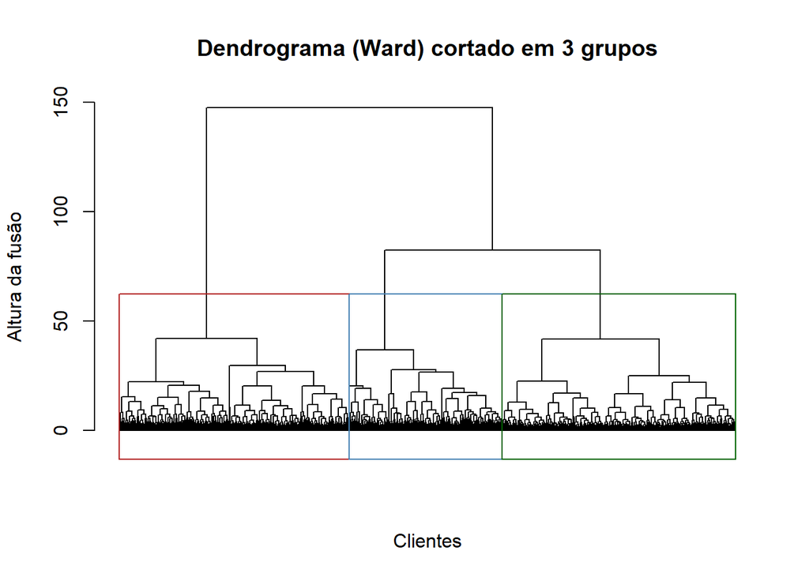

Dendrograma cortado em 3 grupos

```r
# O mesmo dendrograma, com retângulos marcando os k grupos
plot(hc_ward, labels = FALSE, hang = -1,
     main = "Dendrograma (Ward) cortado em 3 grupos", xlab = "Clientes", sub = "",
     ylab = "Altura da fusão")
rect.hclust(hc_ward, k = k_escolhido, border = c("firebrick", "steelblue", "darkgreen"))
```

O corte em 3 grupos gera grupos de **825**, **838** e **549** clientes: nenhum grupo minúsculo, o que é bom para o marketing (não vale a pena criar uma campanha para 10 pessoas). Quem é cada grupo veremos na seção 6; antes, na seção 5, vamos ver o que muda quando as variáveis categóricas entram no agrupamento.

# 5. Hierárquico com dados mistos: distância de Gower

## Motivação: e as variáveis categóricas?

Na seção 3, deixamos de fora a **escolaridade** (`Education`) e o **estado civil** (`Marital_Status`), porque a distância euclidiana só funciona com números: não dá para calcular “PhD menos Graduation”. Mas e se o marketing quiser que esses dados entrem no agrupamento? Precisamos de uma régua que aceite **dados mistos** (números e categorias ao mesmo tempo). A mais conhecida é a **distância de Gower**.

## Como a Gower mede a diferença entre dois clientes

A Gower calcula uma **dissimilaridade** (uma medida de “o quão diferentes” dois clientes são, de 0 = iguais a 1 = o mais diferentes possível) **variável por variável**, e depois tira a **média**:

- **Variável numérica:** a diferença absoluta entre os dois clientes, dividida pela **amplitude** da variável (o maior valor menos o menor valor da base). Assim, cada parcela fica entre 0 e 1, qualquer que seja a unidade. Por isso **não precisamos do `scale()`**: a Gower já coloca as variáveis na mesma escala.
- **Variável categórica:** 0 se os dois clientes estão na mesma categoria, 1 se estão em categorias diferentes.

Em fórmula: com $p$ variáveis, a dissimilaridade de Gower entre os clientes $i$ e $j$ é a média das parcelas $d_{ijk}$ de cada variável $k$:

$$d_G(i, j) = \frac{1}{p} \sum_{k=1}^{p} d_{ijk}$$

em que, para uma **variável numérica**,

$$d_{ijk} = \frac{|x_{ik} - x_{jk}|}{R_k}, \qquad R_k = \max(x_k) - \min(x_k)$$

e, para uma **variável categórica**, $d_{ijk} = 0$ se $x_{ik} = x_{jk}$ e $d_{ijk} = 1$ caso contrário.

Repare que a parcela numérica é exatamente a diferença entre os dois clientes depois da **padronização min-max** da seção 3: como $x_k' = \frac{x_k - \min(x_k)}{R_k}$, temos $|x_{ik}' - x_{jk}'| = \frac{|x_{ik} - x_{jk}|}{R_k}$. Ou seja, a Gower padroniza cada numérica com a min-max e mede a diferença absoluta. (A versão completa da fórmula, na [Wikipedia](https://en.wikipedia.org/wiki/Gower%27s_distance), também permite dar **pesos** diferentes às variáveis e lidar com valores ausentes; aqui, todos os pesos são iguais e não há ausentes.)

Usamos as **mesmas 15 variáveis numéricas** da trilha principal, **com o `log1p()` nos gastos** (isto é, partimos de `dados_cluster`). O log importa aqui também: como a Gower divide pela amplitude, um único cliente com gasto enorme “esticaria” a amplitude, e as diferenças entre todos os outros clientes ficariam minúsculas. Às 15 numéricas, somamos `Education` e `Marital_Status` como **factor** (o tipo do R para variáveis categóricas). A função `daisy()` do pacote `cluster`, com `metric = "gower"`, calcula a matriz de dissimilaridades de uma só vez.

```r
# 5. Hierárquico com dados mistos: distância de Gower ----

# Dados mistos: as 15 numéricas (já com log1p nos gastos) + 2 categóricas como factor
dados_gower <- dados_cluster |>
  mutate(Education = factor(clientes$Education),
         Marital_Status = factor(clientes$Marital_Status))

# Conferindo o tipo de cada coluna: "numeric" ou "factor"
sapply(dados_gower, class)
```

```
             Income               Idade              Filhos             Recency
          "numeric"           "numeric"           "numeric"           "numeric"
           MntWines           MntFruits     MntMeatProducts     MntFishProducts
          "numeric"           "numeric"           "numeric"           "numeric"
   MntSweetProducts        MntGoldProds   NumDealsPurchases     NumWebPurchases
          "numeric"           "numeric"           "numeric"           "numeric"
NumCatalogPurchases   NumStorePurchases   NumWebVisitsMonth           Education
          "numeric"           "numeric"           "numeric"            "factor"
     Marital_Status
           "factor"
```

```r
# Matriz de dissimilaridades de Gower entre todos os pares de clientes
# (não usamos scale(): a Gower divide cada diferença pela amplitude da variável)
dist_gower <- daisy(dados_gower, metric = "gower")

# "mixed" = a daisy reconheceu que há variáveis numéricas e categóricas
attr(dist_gower, "Metric")
```

```
[1] "mixed"
```

```r
# Resumo das dissimilaridades: todas entre 0 e 1
summary(as.vector(dist_gower))
```

```
   Min. 1st Qu.  Median    Mean 3rd Qu.    Max.
 0.0000  0.2096  0.2675  0.2733  0.3329  0.6705
```

A `daisy()` reconheceu os dados como **mistos** (`"mixed"`), e as dissimilaridades vão de **0** a **0,67**, com mediana **0,27**.

### Conferindo à mão, com 2 clientes

A `daisy()` fez a conta para todos os pares de uma vez, como uma “caixa-preta”. Aqui **não** fazemos nada novo: só vamos **refazer o passo a passo da fórmula à mão** para um par de clientes e **conferir** que dá o mesmo valor da função pronta do R. Assim fica claro o que está acontecendo por trás dela.

Vamos refazer a conta para os clientes das linhas **1 e 3** da base. Eles têm a mesma escolaridade (`Graduation`), mas estado civil diferente: um é `Sozinho` e o outro, `Casado/Junto`.

```r
# Os dois clientes que vamos comparar
# (as.data.frame() mostra todas as colunas e mantém os números das linhas da base: 1 e 3)
as.data.frame(dados_gower)[c(1, 3), ]
```

```
  Income Idade Filhos Recency MntWines MntFruits MntMeatProducts
1  58138    57      0      58 6.455199  4.488636        6.304449
3  71613    49      0      26 6.056784  3.912023        4.852030
  MntFishProducts MntSweetProducts MntGoldProds NumDealsPurchases
1        5.153292         4.488636     4.488636                 3
3        4.718499         3.091042     3.761200                 1
  NumWebPurchases NumCatalogPurchases NumStorePurchases NumWebVisitsMonth
1               8                  10                 4                 7
3               8                   2                10                 4
   Education Marital_Status
1 Graduation        Sozinho
3 Graduation   Casado/Junto
```

```r
# Amplitude (maior valor - menor valor) de cada variável numérica
# (\(x) é um atalho do R para function(x): uma função pequena, escrita ali mesmo)
amplitude <- sapply(dados_gower[vars_cluster], \(x) max(x) - min(x))

# Parcela de cada numérica: |diferença| / amplitude (sempre entre 0 e 1)
# (unlist() transforma a linha da tabela num vetor simples de números, para fazer a conta)
parcela_num <- abs(unlist(dados_gower[1, vars_cluster]) -
                   unlist(dados_gower[3, vars_cluster])) / amplitude

# Parcela de cada categórica: 0 se a categoria é a mesma, 1 se é diferente
parcela_cat <- c(
  Education = as.numeric(dados_gower$Education[1] != dados_gower$Education[3]),
  Marital_Status = as.numeric(dados_gower$Marital_Status[1] != dados_gower$Marital_Status[3]))

# As 17 parcelas, arredondadas
round(c(parcela_num, parcela_cat), 3)
```

```
             Income               Idade              Filhos             Recency
              0.084               0.143               0.000               0.323
           MntWines           MntFruits     MntMeatProducts     MntFishProducts
              0.055               0.109               0.195               0.078
   MntSweetProducts        MntGoldProds   NumDealsPurchases     NumWebPurchases
              0.251               0.126               0.133               0.000
NumCatalogPurchases   NumStorePurchases   NumWebVisitsMonth           Education
              0.286               0.462               0.150               0.000
     Marital_Status
              1.000
```

```r
# Gower = média das 17 parcelas
mean(c(parcela_num, parcela_cat))
```

```
[1] 0.1996309
```

```r
# O valor calculado pela daisy() para o mesmo par (linha 1, coluna 3)
as.matrix(dist_gower)[1, 3]
```

```
[1] 0.1996309
```

As duas contas dão o mesmo valor, **0,1996** (cerca de 0,20): os dois clientes são bem parecidos. Repare nas parcelas: a de `Education` é **0** (mesma escolaridade) e a de `Marital_Status` é **1** (estado civil diferente). A maior parcela numérica é a de `NumStorePurchases` (**0,462**), menos da metade da parcela do estado civil. Uma única categórica diferente vale tanto quanto a **maior diferença possível** numa numérica (por exemplo, o cliente mais pobre contra o mais rico da base). Guarde essa observação: ela vai reaparecer quando olharmos a árvore da Gower mais de perto.

## A árvore com a Gower: as quatro regras

Com a matriz de Gower, o cluster hierárquico funciona do mesmo jeito: ele só precisa das dissimilaridades entre os pares. Só trocamos a **régua**. Mas qual **regra de ligação** usar? O Ward foi pensado para a distância euclidiana (ele mede o espalhamento em volta do centro com médias e quadrados), e a Gower não é euclidiana. As regras que só olham para as dissimilaridades entre pares de clientes (**single**, **complete** e **average**) funcionam sem problema. Para comparar, rodamos também o Ward, mas com um **asterisco**: com a Gower, ele perde a interpretação de “espalhamento em volta do centro” e vira só uma regra a mais. (Existe uma adaptação do Ward para a Gower, mas ela fica fora desta aula.)

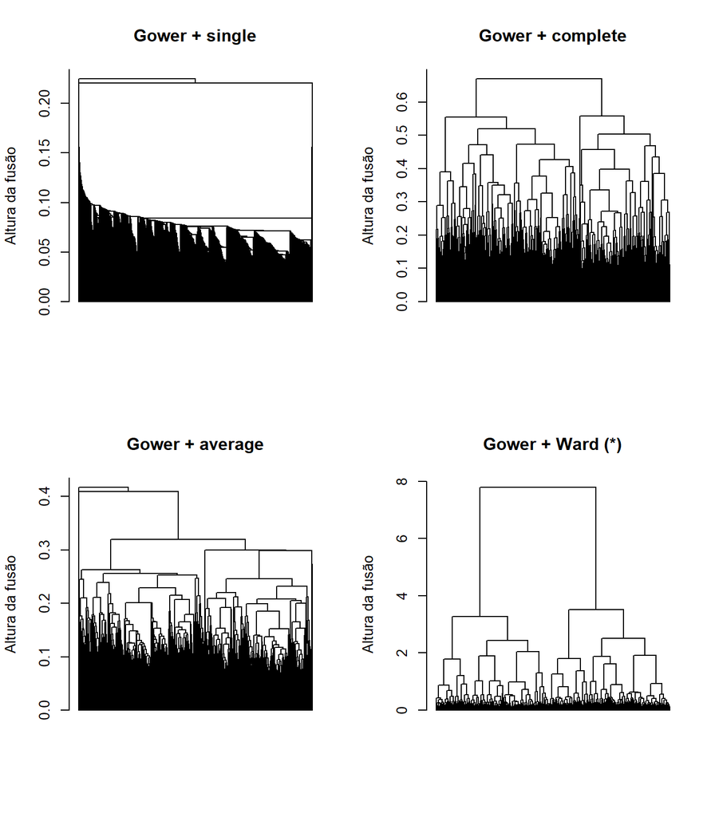

Dendrogramas com a distância de Gower e as quatro regras de ligação. (*) O Ward foi pensado para a distância euclidiana; com a Gower, serve só como comparação.

```r
# Hierárquico com a matriz de Gower e as quatro regras de ligação
hc_gower_single   <- hclust(dist_gower, method = "single")
hc_gower_complete <- hclust(dist_gower, method = "complete")
hc_gower_average  <- hclust(dist_gower, method = "average")
hc_gower_ward     <- hclust(dist_gower, method = "ward.D2")   # só para comparar (veja o texto)

# Os quatro dendrogramas lado a lado
par(mfrow = c(2, 2))
plot(hc_gower_single,   labels = FALSE, hang = -1, main = "Gower + single",   xlab = "", sub = "", ylab = "Altura da fusão")
plot(hc_gower_complete, labels = FALSE, hang = -1, main = "Gower + complete", xlab = "", sub = "", ylab = "Altura da fusão")
plot(hc_gower_average,  labels = FALSE, hang = -1, main = "Gower + average",  xlab = "", sub = "", ylab = "Altura da fusão")
plot(hc_gower_ward,     labels = FALSE, hang = -1, main = "Gower + Ward (*)", xlab = "", sub = "", ylab = "Altura da fusão")
```

```r
par(mfrow = c(1, 1))

# Tamanhos dos grupos quando cortamos cada árvore em 3 grupos
table(cutree(hc_gower_single, k = 3))
```

```
   1    2    3
2207    4    1
```

```r
table(cutree(hc_gower_complete, k = 3))
```

```
   1    2    3
1357  851    4
```

```r
table(cutree(hc_gower_average, k = 3))
```

```
   1    2    3
2207    4    1
```

```r
table(cutree(hc_gower_ward, k = 3))
```

```
   1    2    3
 372 1077  763
```

A **single** e a **average** repetem o que vimos com a distância euclidiana: o corte em 3 deixa **2.207 clientes num grupo só**, e os outros dois têm **4 clientes e 1 cliente**. A **complete** se sai melhor: divide a base em dois grandes grupos, de **1.357** e **851** clientes. O terceiro grupo tem só **4** clientes, então, para a complete, o corte que faz sentido é em **2 grupos**. O **Ward** (com o asterisco) forma, como na seção 4, grupos grandes: **372**, **1.077** e **763** clientes. Os desenhos contam a mesma história da seção 4: a single é uma “escada”, a average só pendura grupinhos no topo, e a complete e o Ward abrem a árvore em dois grandes ramos. Daqui em diante, seguimos com a **complete**, que é uma regra “legítima” para a Gower.

## A régua mudou. Os grupos mudaram?

Vamos cortar a árvore da complete em **2 grupos** e compará-los com os 3 grupos do Ward euclidiano da seção 4 (`grupos_hc`). Lembre que os números dos grupos são só rótulos: o “grupo 1” de uma árvore não tem nada a ver com o “grupo 1” da outra.

```r
# Cortando a árvore da complete (Gower) em 2 grupos
grupos_gower <- cutree(hc_gower_complete, k = 2)

# Tabela cruzada: grupos da Gower (linhas) × grupos do Ward euclidiano (colunas)
table(gower = grupos_gower, ward = grupos_hc)
```

```
     ward
gower   1   2   3
    1 821 107 429
    2   4 731 120
```

```r
# Ward euclidiano: gasto total médio de cada grupo (para saber quem gasta mais)
tapply(clientes$Gasto_total, grupos_hc, mean) |> round()
```

```
   1    2    3
1217   68  514
```

```r
# Estado civil dentro de cada grupo da Gower
table(gower = grupos_gower, estado_civil = clientes$Marital_Status)
```

```
     estado_civil
gower Casado/Junto Sozinho
    1          852     505
    2          576     279
```

Pelo gasto médio, o grupo 1 do Ward é o de **maior gasto** (1.217), o grupo 2 o de **menor gasto** (68) e o grupo 3 o intermediário (514). A tabela cruzada mostra que a Gower reencontrou essencialmente a mesma divisão:

- o grupo 1 da Gower tem **821 dos 825** clientes do grupo de maior gasto;
- o grupo 2 da Gower tem **731 dos 838** clientes do grupo de menor gasto;
- os clientes do grupo intermediário se dividem entre os dois (429 e 120).

### Um número para a concordância: o índice de Rand ajustado

Ler a tabela cruzada dá trabalho, e o resultado depende de quem lê. Uma medida que resume a concordância entre dois agrupamentos num número só é o **índice de Rand ajustado** (ARI, de *Adjusted Rand Index*). A ideia é olhar para **pares de clientes**: para cada par, os dois agrupamentos **concordam** se ambos colocam os dois clientes juntos, ou se ambos os separam. O índice de Rand é a proporção de pares em que há concordância; o ARI desconta a concordância que apareceria **por puro acaso**. Assim:

- **ARI = 1**: os dois agrupamentos são idênticos (a menos dos rótulos dos grupos);
- **ARI ≈ 0**: a concordância é a que se esperaria sorteando os grupos ao acaso;
- valores no meio indicam concordância parcial. O ARI funciona mesmo quando os agrupamentos têm números de grupos diferentes (aqui, 2 e 3).

Para os $n$ clientes, a partir da tabela cruzada com contagens $n_{ab}$ (totais de linha $n_{a\cdot}$ e de coluna $n_{\cdot b}$), e escrevendo $\binom{m}{2} = \frac{m(m-1)}{2}$ para o número de pares:

$$\text{ARI} = \frac{\sum_{a,b} \binom{n_{ab}}{2} - E}{\frac{1}{2}\left[\sum_a \binom{n_{a\cdot}}{2} + \sum_b \binom{n_{\cdot b}}{2}\right] - E},
\qquad E = \frac{\sum_a \binom{n_{a\cdot}}{2} \sum_b \binom{n_{\cdot b}}{2}}{\binom{n}{2}}$$

```r
# Índice de Rand ajustado (ARI) a partir de dois vetores de grupos
# (choose(m, 2) = número de pares que dá para formar com m clientes)
rand_ajustado <- function(grupos_a, grupos_b) {
  tab <- table(grupos_a, grupos_b)
  pares_juntos   <- sum(choose(tab, 2))             # pares juntos nos dois agrupamentos
  pares_linhas   <- sum(choose(rowSums(tab), 2))    # pares juntos no agrupamento A
  pares_colunas  <- sum(choose(colSums(tab), 2))    # pares juntos no agrupamento B
  esperado <- pares_linhas * pares_colunas / choose(sum(tab), 2)   # o que viria do acaso
  (pares_juntos - esperado) / ((pares_linhas + pares_colunas) / 2 - esperado)
}

# Conferindo a função: um agrupamento comparado com ele mesmo dá 1
rand_ajustado(grupos_hc, grupos_hc)
```

```
[1] 1
```

```r
# Concordância entre a Gower (complete, 2 grupos) e o Ward euclidiano (3 grupos)
rand_ajustado(grupos_gower, grupos_hc) |> round(2)
```

```
[1] 0.43
```

O ARI entre a Gower e o Ward euclidiano é **0,43**: uma concordância **moderada**, bem acima do acaso (0), mas longe de idêntica (1). Faz sentido com a tabela: os grupos de maior e de menor gasto são quase os mesmos nas duas réguas, mas o grupo intermediário do Ward é “repartido” pela Gower, que tem só 2 grupos.

E o estado civil **não** decidiu essa divisão: a proporção de casados é parecida nos dois grupos da Gower (852 de 1.357, cerca de **63%**, contra 576 de 855, cerca de **67%**). Mesmo com as duas categóricas na régua, quem separa os clientes, no primeiro corte da árvore, continua sendo **quanto eles gastam**.

E o estado civil? Ele **pesa** na Gower (lembre da conta à mão: a parcela de um estado civil diferente é 1 inteiro, o máximo possível), mas só aparece mais embaixo na árvore. Cortando em **4 grupos**:

```r
# Cortando a mesma árvore em 4 grupos: estado civil em cada grupo
table(gower_4 = cutree(hc_gower_complete, k = 4), estado_civil = clientes$Marital_Status)
```

```
       estado_civil
gower_4 Casado/Junto Sozinho
      1          852     318
      2          572     279
      3            0     187
      4            4       0
```

No corte em 4 aparece um grupo de **187 clientes, todos “Sozinho”**. É o efeito da conta à mão: como a parcela de uma categórica diferente é sempre 1 inteiro (enquanto as parcelas das numéricas costumam ser frações pequenas), o estado civil acaba criando uma “fronteira” própria, mas só nos cortes mais baixos da árvore, depois que a divisão principal (pelo gasto) já foi feita.

**Conclusão:** a régua mudou, mas a **estrutura principal se manteve**: com ou sem as categóricas, os clientes se separam primeiro pelo gasto. Isso nos dá mais confiança nos grupos da seção 4. Para entregar ao marketing, seguimos com os **3 grupos do Ward euclidiano**: eles usam só as variáveis de comportamento de compra e dividem a base em 3 grupos de tamanhos úteis. Incluir variáveis (como o estado civil) é sempre uma **escolha**, e o analista precisa olhar o resultado e perguntar se os grupos respondem à pergunta do negócio.

# 6. Resultados para o negócio

Os segmentos que vão para o marketing são os **3 grupos do Ward com a distância euclidiana** (seção 4): eles separam os clientes pelo **comportamento de compra**, e a seção 5 mostrou que a estrutura principal se mantém mesmo quando a régua muda.

```r
# 6. Resultados para o negócio ----

# Os grupos que vão para o marketing: os do Ward euclidiano (seção 4)
grupos_final <- grupos_hc

# Conferindo: tamanho de cada grupo
table(grupos_final)
```

```
grupos_final
  1   2   3
825 838 549
```

Falta o mais importante: **traduzir os grupos em linguagem de negócio**. Vamos (1) visualizar os grupos, (2) descrever cada um nas variáveis originais, (3) dar um nome a cada segmento, (4) escrever as fichas e (5) conferir se os segmentos respondem de forma diferente às campanhas.

## Visualizando os grupos em 2D: PCA

Cada cliente é descrito por 15 variáveis, e não dá para desenhar um gráfico com 15 eixos. A **PCA** (*análise de componentes principais*) resolve isso: ela cria novas variáveis, os **componentes principais**, que são combinações das 15 originais. O **1º componente** é a direção em que os clientes **mais variam**; o 2º é a direção que mais varia entre as que sobram, e assim por diante. Desenhando só os 2 primeiros, temos um “mapa” dos clientes que perde um pouco de informação, mas guarda o principal.

A **variância explicada** diz quanto da variação total dos dados cada componente “guarda”. Usamos a função `prcomp()` sobre `dados_pad` (os dados já padronizados).

```r
# PCA nos dados padronizados (as mesmas 15 variáveis do agrupamento)
pca <- prcomp(dados_pad)

# Variância explicada pelos 4 primeiros componentes:
# "Proportion of Variance" = de cada componente; "Cumulative Proportion" = acumulada
summary(pca)$importance[, 1:4] |> round(3)
```

```
                         PC1   PC2   PC3   PC4
Standard deviation     2.617 1.347 1.089 1.002
Proportion of Variance 0.457 0.121 0.079 0.067
Cumulative Proportion  0.457 0.578 0.657 0.724
```

```r
# Peso de cada variável nos 2 primeiros componentes (ajuda a "ler" os eixos)
round(pca$rotation[, 1:2], 2)
```

```
                      PC1   PC2
Income              -0.32  0.00
Idade               -0.06  0.23
Filhos               0.21  0.42
Recency             -0.01  0.01
MntWines            -0.32  0.25
MntFruits           -0.30 -0.10
MntMeatProducts     -0.36  0.07
MntFishProducts     -0.30 -0.11
MntSweetProducts    -0.30 -0.10
MntGoldProds        -0.26  0.15
NumDealsPurchases    0.02  0.61
NumWebPurchases     -0.23  0.39
NumCatalogPurchases -0.30 -0.03
NumStorePurchases   -0.30  0.13
NumWebVisitsMonth    0.23  0.34
```

O 1º componente guarda **45,7%** da variação e o 2º, **12,1%**: juntos, **57,8%**. O mapa em 2D mostra, portanto, pouco mais da metade da informação, e grupos que parecem “encostados” no mapa podem estar mais separados nas outras dimensões.

Lendo os pesos: no 1º componente, todos os **gastos**, a **renda** e as compras por catálogo e na loja têm pesos parecidos (em torno de −0,3), e `Filhos` e `NumWebVisitsMonth` têm peso positivo. Ele mede, em resumo, **“quanto o cliente gasta”**. O sinal de um componente é arbitrário (trocar todos os sinais dá o mesmo componente), então no gráfico multiplicamos o 1º por −1 para que **a direita seja “gasta mais”**. No 2º componente, os maiores pesos são de `NumDealsPurchases` (0,61), `Filhos` (0,42), `NumWebPurchases` (0,39) e `NumWebVisitsMonth` (0,34): ele mede **“compra com desconto, pela internet, e tem filhos”**.

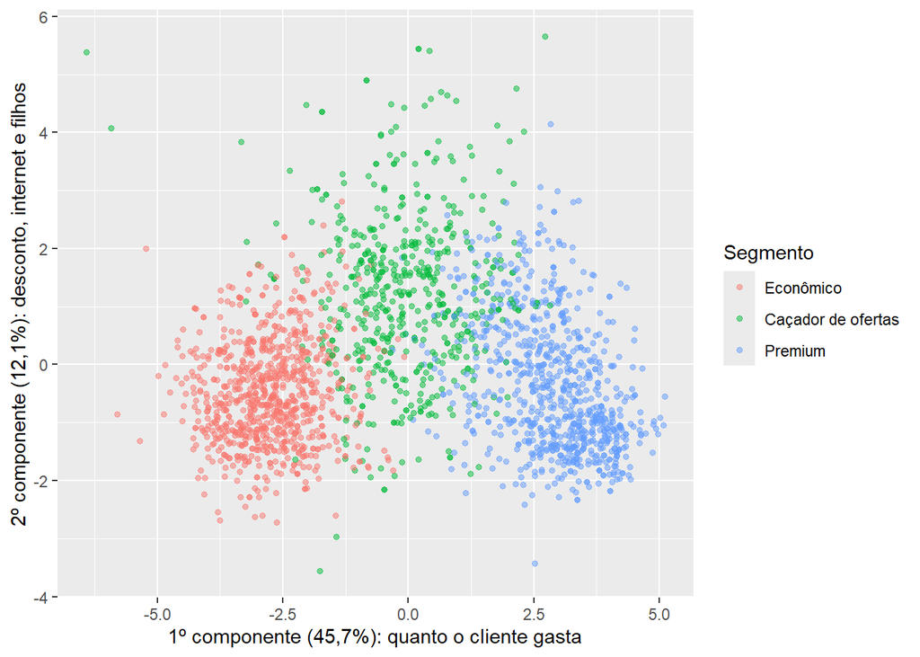

Clientes nos 2 primeiros componentes principais, coloridos pelo segmento (grupo do Ward)

```r
# Nomes dos segmentos, do MENOR para o MAIOR gasto total médio (a regra é explicada na próxima seção)
nomes_segmentos <- c("Econômico", "Caçador de ofertas", "Premium")

# Gasto total médio de cada grupo do Ward; rank() dá a posição do grupo (1 = menor gasto)
gasto_medio_grupo <- tapply(clientes$Gasto_total, grupos_final, mean)
segmento_pca <- nomes_segmentos[rank(gasto_medio_grupo)[grupos_final]]

# Coordenadas de cada cliente nos 2 primeiros componentes, mais o nome do segmento
# (o 1º componente é multiplicado por -1 só para a direita significar "gasta mais")
pontos_pca <- tibble(CP1 = -pca$x[, "PC1"],
                     CP2 = pca$x[, "PC2"],
                     segmento = factor(segmento_pca, levels = nomes_segmentos))

# Gráfico de dispersão: um ponto por cliente, cor = segmento
pontos_pca |>
  ggplot(aes(x = CP1, y = CP2, color = segmento)) +
  geom_point(alpha = 0.5, size = 1.2) +
  labs(x = "1º componente (45,7%): quanto o cliente gasta",
       y = "2º componente (12,1%): desconto, internet e filhos",
       color = "Segmento")
```

Os três grupos aparecem **lado a lado ao longo do 1º componente**: o **Econômico** à esquerda (gasta pouco), o **Premium** à direita (gasta muito) e o **Caçador de ofertas** no meio, mais “para cima” no 2º componente (mais desconto, internet e filhos). As fronteiras entre os grupos não são vazias, e os pontos se tocam (lembre que, na base real, a single, a complete e a average não acharam grupos separados): os segmentos são “fatias” de um contínuo ao longo de “quanto o cliente gasta”. O agrupamento foi feito com as 15 variáveis, e não com este mapa: a PCA aqui serve **só para visualizar**.

## Perfil de cada grupo e os nomes dos segmentos

Agora descrevemos cada grupo nas **variáveis originais** (sem log e sem padronização), que o marketing entende: renda em US$, número de filhos, gasto em 2 anos e assim por diante. Usamos médias, e para o gasto total também a mediana (lembre que o gasto tem cauda longa).

**Os nomes.** Precisamos dar um nome a cada grupo, mas **não podemos amarrar o nome ao número do grupo** (do tipo “grupo 1 = Premium”): os números são rótulos arbitrários e podem mudar se alguém trocar a técnica, os dados ou a versão de um pacote. Se mudarem, a ficha passaria a descrever o grupo errado, sem nenhum aviso. Por isso, o nome é dado por uma **regra sobre o perfil**: ordenamos os grupos pelo **gasto total médio**, do menor para o maior, e damos os nomes nessa ordem.

```r
# Perfil de cada grupo nas variáveis originais (médias; "_medio" no nome da coluna)
perfil_segmentos <- clientes |>
  mutate(grupo = grupos_final) |>
  group_by(grupo) |>
  summarise(n = n(),
            # across(): aplica a média a várias colunas de uma vez
            across(c(Income, Idade, Filhos, Kidhome, Teenhome, Recency,
                     Gasto_total, Compras_total, MntWines, MntMeatProducts,
                     NumDealsPurchases, NumWebPurchases, NumCatalogPurchases,
                     NumStorePurchases, NumWebVisitsMonth, Tempo_casa_dias),
                   mean, .names = "{.col}_medio"),
            Gasto_total_mediano = median(Gasto_total),
            # proporção de clientes sem filhos em casa
            Sem_filhos_prop = mean(Filhos == 0),
            # quanto (%) do gasto de TODA a base vem deste grupo
            Receita_pct = 100 * sum(Gasto_total) / sum(clientes$Gasto_total))

# Nomes dos segmentos, do MENOR para o MAIOR gasto total médio
nomes_segmentos <- c("Econômico", "Caçador de ofertas", "Premium")

# Regra: ordenar os grupos pelo gasto total médio e dar os nomes nessa ordem
# (o nome depende do perfil, e não do número que a técnica deu ao grupo)
perfil_segmentos <- perfil_segmentos |>
  arrange(Gasto_total_medio) |>
  mutate(segmento = factor(nomes_segmentos, levels = nomes_segmentos), .before = 1)

# Base de clientes com o nome do segmento de cada um
clientes_seg <- clientes |>
  mutate(grupo = grupos_final) |>
  left_join(perfil_segmentos |> select(grupo, segmento), by = "grupo")

# Quantos clientes em cada segmento?
clientes_seg |> count(segmento)
```

```
# A tibble: 3 × 2
  segmento               n
  <fct>              <int>
1 Econômico            838
2 Caçador de ofertas   549
3 Premium              825
```

```r
# O perfil "deitado": uma linha por variável e uma coluna por segmento (mais fácil de ler)
perfil_segmentos |>
  select(-grupo) |>
  pivot_longer(-segmento, names_to = "variavel", values_to = "valor") |>
  mutate(valor = round(valor, 2)) |>
  pivot_wider(names_from = segmento, values_from = valor) |>
  as.data.frame()
```

```
                    variavel Econômico Caçador de ofertas  Premium
1                          n    838.00             549.00   825.00
2               Income_medio  32412.67           51900.32 71851.87
3                Idade_medio     42.16              47.56    46.42
4               Filhos_medio      1.27               1.21     0.45
5              Kidhome_medio      0.82               0.43     0.06
6             Teenhome_medio      0.45               0.78     0.38
7              Recency_medio     47.63              51.99    48.45
8          Gasto_total_medio     68.00             514.23  1216.94
9        Compras_total_medio      5.16              13.49    19.48
10            MntWines_medio     28.59             329.12   570.49
11     MntMeatProducts_medio     15.27              89.36   372.87
12   NumDealsPurchases_medio      1.84               3.81     1.83
13     NumWebPurchases_medio      1.79               5.46     5.52
14 NumCatalogPurchases_medio      0.39               2.09     5.38
15   NumStorePurchases_medio      2.98               5.95     8.59
16   NumWebVisitsMonth_medio      6.53               6.41     3.38
17     Tempo_casa_dias_medio    313.53             397.44   365.44
18       Gasto_total_mediano     54.00             416.00  1168.00
19           Sem_filhos_prop      0.11               0.10     0.59
20               Receita_pct      4.24              21.02    74.74
```

O que o perfil mostra (médias, salvo indicação):

- **Econômico (838 clientes):** a menor renda (**US$ 32.413**) e um gasto muito baixo (**US$ 68** em 2 anos; mediana **US$ 54**), com só **5 compras**. Tem crianças pequenas em casa (`Kidhome` **0,82**) e visita **muito** o site (**6,5 visitas por mês**), mas compra pouco por lá (**1,8** compras). Responde por só **4%** do gasto total da base.
- **Caçador de ofertas (549 clientes):** renda intermediária (**US$ 51.900**) e gasto de **US$ 514**. É o grupo que **mais compra com desconto** (**3,8** compras com desconto, mais que o dobro dos outros dois, ambos com 1,8) e compra bastante pelo site (**5,5**, empatado com o Premium). Tem **adolescentes** em casa (`Teenhome` **0,78**). Responde por **21%** do gasto.
- **Premium (825 clientes):** a maior renda (**US$ 71.852**) e o maior gasto (**US$ 1.217**), puxado por **vinhos** (US$ 570) e **carnes** (US$ 373). **59%** não têm filhos em casa. Compra muito na loja (**8,6**) e pelo catálogo (**5,4**), usa pouco desconto (**1,8**) e entra pouco no site (**3,4** visitas por mês). Sozinho, responde por **75%** de todo o gasto da base.

Repare que `Recency` (dias desde a última compra) é parecida nos três segmentos (entre **48** e **52** dias): os grupos não se separam por “quem comprou recentemente”, e sim por **quanto e como** compram.

## Gráfico de perfil

Um **mapa de calor** resume o perfil nas 15 variáveis do agrupamento. Cada casa mostra a **média padronizada** do segmento: 0 é a média da base, valores positivos (azul) estão acima da média e negativos (vermelho), abaixo, medidos em desvios-padrão. Lembre que, nos gastos (`Mnt*`), a padronização foi feita depois do log.

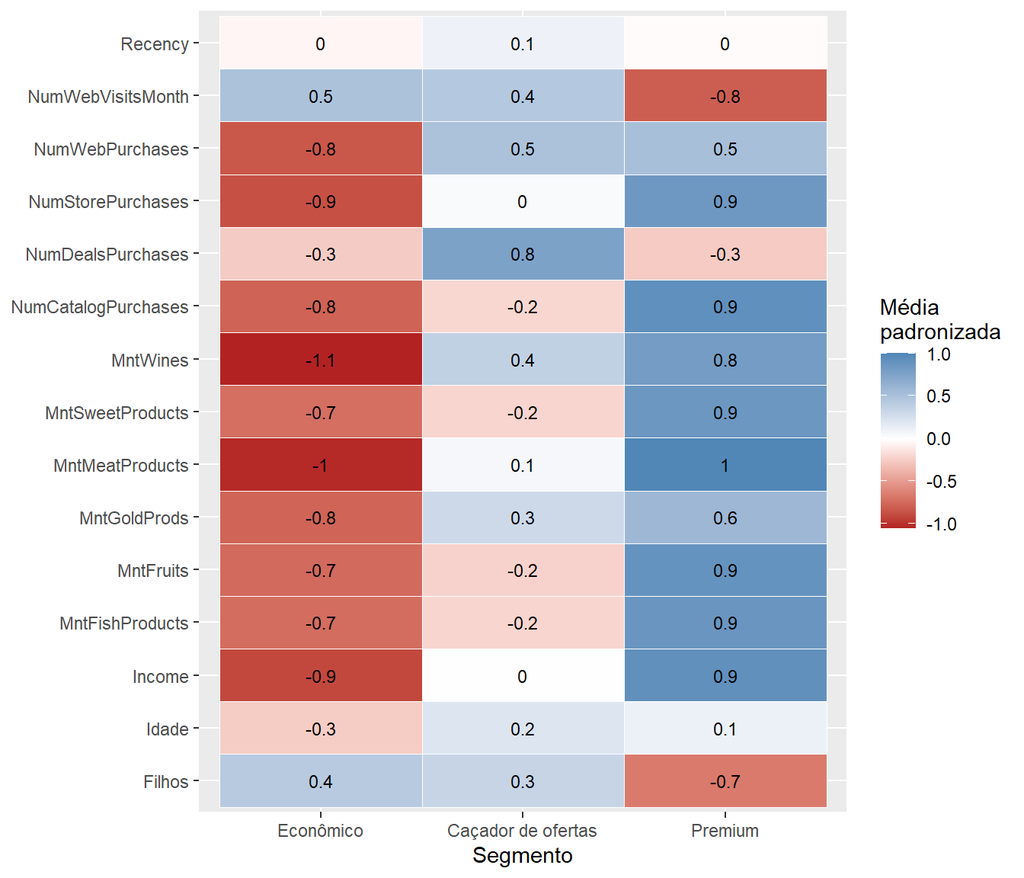

Média padronizada de cada variável por segmento (0 = média da base)

```r
# Médias das variáveis padronizadas (dados_pad) dentro de cada segmento
medias_pad <- as_tibble(dados_pad) |>
  mutate(segmento = clientes_seg$segmento) |>
  group_by(segmento) |>
  summarise(across(everything(), mean)) |>
  # formato longo: uma linha por segmento e variável
  pivot_longer(-segmento, names_to = "variavel", values_to = "media_padronizada")

# Mapa de calor: cor = média padronizada; o número dentro de cada casa é o valor
medias_pad |>
  ggplot(aes(x = segmento, y = variavel, fill = media_padronizada)) +
  geom_tile(color = "white") +
  geom_text(aes(label = round(media_padronizada, 1)), size = 3) +
  # vermelho = abaixo da média, branco = na média, azul = acima da média
  scale_fill_gradient2(low = "firebrick", mid = "white", high = "steelblue", midpoint = 0) +
  labs(x = "Segmento", y = NULL, fill = "Média\npadronizada")
```

O mapa confirma a leitura: o **Premium** é azul em todos os gastos, na renda e nas compras por catálogo e loja, e vermelho em `Filhos`, `NumDealsPurchases` e `NumWebVisitsMonth`. O **Econômico** é o “espelho” do Premium: vermelho em quase tudo e azul só em `Filhos` e `NumWebVisitsMonth`. O **Caçador de ofertas** se destaca em azul em `NumDealsPurchases` (**0,8**) e em `NumWebPurchases` (**0,5**, como o Premium); nos gastos, fica acima da média em vinhos (**0,4**) e produtos “ouro” (**0,3**) e perto da média nas outras categorias.

## As fichas de segmento

Esta é a **entrega para o marketing**: uma ficha por segmento, com o perfil em linguagem de negócio e uma ação sugerida. Os números do perfil saem direto de `perfil_segmentos` (se os dados mudarem, as fichas mudam junto). As frases e as ações foram escritas a partir do perfil que acabamos de ver, na mesma ordem dos nomes (do menor para o maior gasto). Atenção: essas descrições (e o próprio nome “Caçador de ofertas”) valem **para estes dados**; se os dados, as variáveis ou a técnica mudarem, elas precisam ser **revistas** à luz do novo perfil, porque a regra de ordem só garante quem gasta mais ou menos, e não o resto da descrição.

```r
# Função auxiliar: número no formato brasileiro (ponto no milhar, vírgula decimal)
fmt <- function(x, casas = 0) {
  formatC(x, format = "f", digits = casas, big.mark = ".", decimal.mark = ",")
}

# Atalho para não repetir "perfil_segmentos$" (as linhas estão em ordem crescente de gasto)
p <- perfil_segmentos

# Resumo em palavras de cada segmento, na ordem: Econômico, Caçador de ofertas, Premium
resumos <- c(
  "Renda mais baixa e gasto muito baixo; famílias com crianças pequenas; visita bastante o site, mas compra pouco.",
  "Renda intermediária; o grupo que mais compra com desconto; compra bastante pelo site; famílias com adolescentes.",
  "Renda alta e o maior gasto, puxado por vinhos e carnes; a maioria sem filhos em casa; compra na loja e pelo catálogo e usa pouco desconto.")

# Ação de marketing sugerida para cada segmento, na mesma ordem
acoes <- c(
  "Canais baratos (e-mail, site): ofertas de entrada em itens básicos e infantis e um cupom para a primeira compra online, para transformar as muitas visitas ao site em compras. Evitar catálogo impresso, caro para quem gasta pouco.",
  "Promoções e programa de pontos: combos para a família (vinho + carne) com desconto progressivo e ofertas relâmpago no site. Objetivo: aumentar o valor de cada compra sem depender só de desconto.",
  "Relacionamento e exclusividade, não desconto: catálogo de vinhos e carnes selecionados, pré-lançamentos e degustações na loja. Objetivo: reter estes clientes, que geram a maior parte da receita.")

# As fichas: segmento, perfil (resumo + números do perfil real) e ação
# (sprintf() encaixa cada número, na ordem, no lugar de um %s do texto; %% vira o símbolo %)
fichas <- tibble(
  segmento = p$segmento,
  perfil = paste(resumos,
                 sprintf("%s clientes (%s%% do gasto total); renda média de US$ %s; gasto médio de US$ %s em 2 anos, em %s compras; %s filho(s) em casa; %s compras com desconto; %s visitas ao site por mês.",
                         fmt(p$n), fmt(p$Receita_pct), fmt(p$Income_medio),
                         fmt(p$Gasto_total_medio), fmt(p$Compras_total_medio, 1),
                         fmt(p$Filhos_medio, 2), fmt(p$NumDealsPurchases_medio, 1),
                         fmt(p$NumWebVisitsMonth_medio, 1))),
  acao = acoes)

# Mostrando cada ficha (strwrap quebra o texto longo em linhas de até 80 caracteres)
for (i in seq_len(nrow(fichas))) {
  cat("==== Segmento:", as.character(fichas$segmento[i]), "====\n")
  cat("PERFIL:", strwrap(fichas$perfil[i], 80), sep = "\n")
  cat("AÇÃO:", strwrap(fichas$acao[i], 80), sep = "\n")
  cat("\n")
}
```

```
==== Segmento: Econômico ====
PERFIL:
Renda mais baixa e gasto muito baixo; famílias com crianças pequenas; visita
bastante o site, mas compra pouco. 838 clientes (4% do gasto total); renda
média de US$ 32.413; gasto médio de US$ 68 em 2 anos, em 5,2 compras; 1,27
filho(s) em casa; 1,8 compras com desconto; 6,5 visitas ao site por mês.
AÇÃO:
Canais baratos (e-mail, site): ofertas de entrada em itens básicos e infantis e
um cupom para a primeira compra online, para transformar as muitas visitas ao
site em compras. Evitar catálogo impresso, caro para quem gasta pouco.

==== Segmento: Caçador de ofertas ====
PERFIL:
Renda intermediária; o grupo que mais compra com desconto; compra bastante pelo
site; famílias com adolescentes. 549 clientes (21% do gasto total); renda média
de US$ 51.900; gasto médio de US$ 514 em 2 anos, em 13,5 compras; 1,21 filho(s)
em casa; 3,8 compras com desconto; 6,4 visitas ao site por mês.
AÇÃO:
Promoções e programa de pontos: combos para a família (vinho + carne) com
desconto progressivo e ofertas relâmpago no site. Objetivo: aumentar o valor de
cada compra sem depender só de desconto.

==== Segmento: Premium ====
PERFIL:
Renda alta e o maior gasto, puxado por vinhos e carnes; a maioria sem filhos em
casa; compra na loja e pelo catálogo e usa pouco desconto. 825 clientes (75% do
gasto total); renda média de US$ 71.852; gasto médio de US$ 1.217 em 2 anos, em
19,5 compras; 0,45 filho(s) em casa; 1,8 compras com desconto; 3,4 visitas ao
site por mês.
AÇÃO:
Relacionamento e exclusividade, não desconto: catálogo de vinhos e carnes
selecionados, pré-lançamentos e degustações na loja. Objetivo: reter estes
clientes, que geram a maior parte da receita.
```

## Os clientes-exemplo de cada segmento

Uma tabela de médias é útil, mas o marketing entende melhor **uma pessoa**: “este é o cliente típico do segmento”. Para cada segmento, escolhemos o **cliente mais parecido com o perfil médio do grupo**: calculamos a média de cada uma das 15 variáveis padronizadas dentro do segmento (o “cliente médio”, que não existe de verdade) e procuramos o cliente real **mais perto** dessa média, com a mesma distância euclidiana de sempre. É a mesma conta dos “vizinhos mais próximos” da seção 3.

```r
# Para cada segmento: a linha da base do cliente mais perto do perfil médio do segmento
posicao_exemplo <- sapply(levels(clientes_seg$segmento), function(s) {
  linhas <- which(clientes_seg$segmento == s)        # clientes deste segmento
  media <- colMeans(dados_pad[linhas, ])             # perfil médio (variáveis padronizadas)
  dif <- sweep(dados_pad[linhas, ], 2, media)        # diferença de cada cliente até a média
  linhas[which.min(sqrt(rowSums(dif^2)))]            # o cliente com a menor distância
})

# Os clientes-exemplo, com algumas variáveis fáceis de interpretar
clientes_exemplo <- clientes_seg[posicao_exemplo, ] |>
  select(segmento, ID, Income, Idade, Filhos, Gasto_total, Compras_total,
         NumDealsPurchases, NumWebPurchases, NumWebVisitsMonth)
as.data.frame(clientes_exemplo)
```

```
            segmento    ID Income Idade Filhos Gasto_total Compras_total
1          Econômico  5267  33986    44      1          44             4
2 Caçador de ofertas 10260  45143    49      1         311            12
3            Premium 10383  70287    48      0        1093            20
  NumDealsPurchases NumWebPurchases NumWebVisitsMonth
1                 1               1                 7
2                 3               6                 7
3                 1               5                 3
```

Para apresentar ao marketing:

- **Econômico:** o cliente **5267**, com renda de US$ 33.986, 1 filho, gasto de **US$ 44** em 2 anos e **7 visitas ao site por mês**, mas só 1 compra pela internet.
- **Caçador de ofertas:** o cliente **10260**, com renda de US$ 45.143, 1 filho, gasto de **US$ 311**, **12 compras**, 3 delas com desconto.
- **Premium:** o cliente **10383**, com renda de US$ 70.287, **sem filhos**, gasto de **US$ 1.093** e **20 compras**.

## Validação externa: os segmentos respondem diferente às campanhas?

Até aqui, os segmentos foram formados **sem olhar** para as campanhas: `AcceptedCmp1` a `5` e `Response` ficaram de fora da clusterização (seção 3). Por isso podemos usá-las agora como uma **validação externa**: um teste com informação que **o algoritmo não viu**. Se os segmentos respondem de forma bem diferente às campanhas, é um sinal de que eles capturam algo real sobre o comportamento dos clientes, e não só “ruído” das 15 variáveis.

Atenção: isto é só uma **conferência**. As taxas de resposta **não entraram** na formação dos grupos, nem devem entrar: se entrassem, a validação seria circular (o grupo “responde mais” porque foi montado com quem respondeu).

```r
# Taxas de aceite de campanhas em cada segmento
# Response = aceitou a última campanha (0 ou 1); a média de 0/1 é a proporção de "sim"
resposta_por_segmento <- clientes_seg |>
  group_by(segmento) |>
  summarise(n = n(),
            taxa_resposta = mean(Response),
            # aceitou ALGUMA das 6 campanhas (as 5 anteriores ou a última)?
            taxa_alguma_campanha = mean(AcceptedCmp1 + AcceptedCmp2 + AcceptedCmp3 +
                                          AcceptedCmp4 + AcceptedCmp5 + Response > 0))
resposta_por_segmento
```

```
# A tibble: 3 × 4
  segmento               n taxa_resposta taxa_alguma_campanha
  <fct>              <int>         <dbl>                <dbl>
1 Econômico            838        0.0895                0.142
2 Caçador de ofertas   549        0.138                 0.290
3 Premium              825        0.221                 0.395
```

```r
# Para comparar: taxa de resposta na base inteira
mean(clientes_seg$Response)
```

```
[1] 0.1505425
```

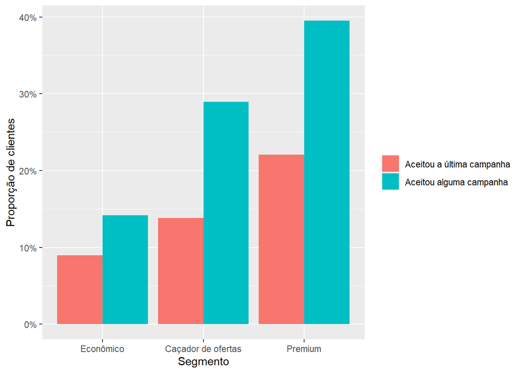

Aceite de campanhas por segmento (validação externa)

```r
# Gráfico de barras com as duas taxas lado a lado, por segmento
resposta_por_segmento |>
  pivot_longer(c(taxa_resposta, taxa_alguma_campanha),
               names_to = "medida", values_to = "taxa") |>
  mutate(medida = if_else(medida == "taxa_resposta",
                          "Aceitou a última campanha", "Aceitou alguma campanha")) |>
  ggplot(aes(x = segmento, y = taxa, fill = medida)) +
  geom_col(position = "dodge") +
  # eixo y em porcentagem (scales vem junto com o tidyverse)
  scale_y_continuous(labels = scales::percent) +
  labs(x = "Segmento", y = "Proporção de clientes", fill = NULL)
```

As taxas **crescem com o gasto**: aceitaram a última campanha **8,9%** dos Econômicos, **13,8%** dos Caçadores de ofertas e **22,1%** dos Premium (na base inteira, **15,1%**). Considerando as 6 campanhas, **14,2%**, **29,0%** e **39,5%** aceitaram pelo menos uma. Ou seja, os clientes Premium **aceitaram** a última campanha numa proporção cerca de **2,5 vezes** maior que os Econômicos: os segmentos, formados sem olhar para as campanhas, também diferem na aceitação, o que é um bom sinal de que capturam algo real.

Dois cuidados ao ler esse resultado. Primeiro, ele é **mais fraco do que parece**: os segmentos foram montados, em boa parte, a partir do **gasto**, e é esperado que quem gasta mais também aceite mais ofertas. Uma diferença grande na aceitação era, portanto, o resultado previsível, e não uma surpresa. Segundo, isto é uma **associação**, e não o **efeito** da campanha: não sabemos se o Premium aceita mais **por causa** da campanha ou se compraria de qualquer jeito. Para medir o efeito, seria preciso um experimento (por exemplo, sortear quem recebe a campanha e comparar com quem não recebe), assunto para outra aula.

## Para fechar

- Partimos de um problema de negócio (campanhas iguais para todos) e chegamos a **3 segmentos com nome, perfil, cliente-exemplo e ação**.
- Cada escolha mudou o resultado e foi **mostrada**: quais variáveis entram, log e padronização, a **regra de ligação** (single, complete e average não serviram para esta base; o Ward, sim), o *k* (a árvore sugeria 2 ou 3) e a **régua** (euclidiana ou Gower).
- Com a Gower, a ligação complete reencontrou essencialmente **a mesma divisão por gasto** do Ward euclidiano (índice de Rand ajustado de **0,43**, uma concordância moderada): a estrutura principal não depende da régua. Mas as fronteiras são difusas (os clientes formam um contínuo): os segmentos são **tipos predominantes**, não caixas fechadas.
- A validação com as campanhas, que **não** entraram no agrupamento, mostrou que os segmentos também diferem na aceitação das campanhas. É uma associação (e esperada, já que os segmentos se separam pelo gasto), não uma medida do efeito das campanhas.
- Existem outras técnicas de agrupamento (como o k-means e o k-medoides), que dividem a base sem construir uma árvore; elas ficam para outra aula.